# ENVS2018 Environmental Science Field School: Kioloa analyses

Shoshana Rapley, Saul Cunningham

20 September 2023

# 1 Background

The purpose of the Kioloa week report is to report on the patterns of biodiversity we observed. In particular, you should examine the composition and structure of different plant communities at Kioloa, whether animal (bird) communities also differ, and consider how these patterns relate to the underlying soils and geology.

We are excited to share the whole-class survey results with you all, because there are some really interesting patterns here. Keep in mind when writing the reports that we want you to use this data summary as source material. We are not expecting that you do further, more complex analyses. You can focus on the summary data that we have provided. You may also use the figures/graphs from this markdown in your report.

# 2 Markdown

This document is called a ‘markdown’. It’s a way to share code, annotations and results all in one place, how good!

If you are interested in the code you can unfold the chunks by clicking the ‘Show’ icon. There is also an option on the top right of the document called ‘Code’ that allows you to show or hide all code chunks. Notes in the code itself that start with a hash explain what the next line of code achieves.

```r
# Install and load required packages
pacman::p_load(dplyr, gdata, ggplot2, ggrepel, gt, gtExtras, janitor, lme4, lubridate,
               rstudioapi, readxl, sjmisc, tidyr, tidyverse, vegan)
```

# 3 Vegetation communities

We collected vegetation data using the biometric tool methodology. This included compositional elements (e.g. overstory trees) and functional elements (e.g. woody debris).

## 3.1 Floral composition

Let’s start by looking at a matrix of the floral composition.

The species composition table has each site as a row, and each column is a plant species. The number 1 means the species was present in the composition survey. In some cases the plant species have been organised into groups that are similar, as follows.

- Block 1 are trees species that occupy the overstory
- Block 2 are mid story species that are recognised as favouring rainforest vegetation (according to https://plantnet.rbgsyd.nsw.gov.au/)
- Block 3 are species in the genus *Acacia*, which occur in the mid story
- Block 4 are ferns
- Block 5 are grasses
- Block 6 are plants in the family *Cyperaceae*, which we call “true sedges”. *Lomandra longifolia* is sometimes grouped with the sedges but is actually a different plant family

The other species (in grey) are not blocked, but plants in the same genus are put next to each other.

Note that as you progress down the rows of the table you have species that are not blocked with similar species, and which are found in relatively few sites. Therefore they are less useful in interpreting the similarities and differences in composition of the plant communities.

```r
# read in the data
comp_data <- read_excel("data/ENVS2018 kioloa flora composition 2023.xlsx", sheet = 2)

# create a pretty table using the package 'gt'
comp_table <- gt(comp_data) %>%
  tab_options(data_row.padding = px(1)) %>%
  # change font size
  tab_style(style = cell_text(size = px(12)), locations = cells_column_labels()) %>%
  tab_style(style = cell_text(size = px(10)), locations = cells_body()) %>%
  # add header
  tab_header(title = "Floral composition",
             subtitle = "ENVS2018 Student data Kioloa 2023") %>%
  # replace NAs with blanks
  tab_style(cell_text(style = "italic"),locations = cells_body(columns = 2)) %>%
  sub_missing(missing_text = " ") %>%
  # add row colours for plant type (using a 7 colour viridis scale)
  tab_style(style = list(cell_fill(color = "#440154CC"), cell_text(color = "white")),
    locations = cells_body(columns = 1:2, rows = 1:7)) %>%
  tab_style(style = list(cell_fill(color = "#443A83CC"), cell_text(color = "white")),
    locations = cells_body(columns = 1:2, rows = 8:13)) %>%
  tab_style(style = list(cell_fill(color = "#31688ECC"), cell_text(color = "white")),
    locations = cells_body(columns = 1:2, rows = 14:20)) %>%
  tab_style(style = list(cell_fill(color = "#21908CCC"), cell_text(color = "white")),
    locations = cells_body(columns = 1:2, rows = 21:24)) %>%
  tab_style(style = list(cell_fill(color = "#35B779CC")),
    locations = cells_body(columns = 1:2, rows = 25:33)) %>%
  tab_style(style = list(cell_fill(color = "#8FD744CC")),
    locations = cells_body(columns = 1:2, rows = 34:39)) %>%
  tab_style(style = list(cell_fill(color = "#EAEAEA")),
    locations = cells_body(columns = 1:2, rows = 40:80)) %>%
  # change tally colour
  tab_style(style = list(cell_fill(color = "lightgrey")),
    locations = cells_body(columns = 23))

comp_table
```

Floral composition

ENVS2018 Student data Kioloa 2023

| type | Species | OG10 | OG5 | OG7 | OG9 | RF1 | RF2 | RF3 | RF4 | RG10 | RG1 | RG3 | RG4 | RG8 | C1 | C2 | OG1 | RG2 | C3 | C4 | C5 | Total |
| --- | --- | --- | --- | --- | --- | --- | --- | --- | --- | --- | --- | --- | --- | --- | --- | --- | --- | --- | --- | --- | --- | --- |
| overstorey | Corymbia maculata | 1 | 1 | 1 | 1 | 1 | 1 | 1 |  | 1 | 1 | 1 | 1 | 1 | 1 | 1 | 1 | 1 |  |  |  | 16 |
| overstorey | Eucalyptus pilularis | 1 | 1 | 1 | 1 | 1 |  | 1 |  | 1 |  |  | 1 | 1 |  |  |  |  |  |  |  | 9 |
| overstorey | Eucalyptus saligna |  |  |  |  |  |  |  |  |  |  |  |  | 1 |  |  |  |  |  |  |  | 1 |
| overstorey | Eucalyptus tereticornis |  |  |  |  |  |  |  |  |  | 1 |  |  | 1 |  |  |  |  |  |  |  | 2 |
| overstorey | Eucalyptus botryoides |  |  |  |  |  |  |  | 1 |  |  |  |  |  | 1 | 1 | 1 | 1 |  |  |  | 5 |
| overstorey | Eucalyptus globoidea |  |  |  |  |  |  |  |  |  |  |  |  |  | 1 |  |  |  |  |  |  | 1 |
| overstorey | Casuarina glauca |  |  |  |  |  |  |  |  |  |  |  |  |  |  |  |  |  | 1 | 1 | 1 | 3 |
| mid, rainforest loving | Backhousia myrtifolia |  |  |  |  |  | 1 | 1 | 1 |  |  |  |  |  |  |  |  |  |  |  |  | 3 |
| mid, rainforest loving | Doryphora sassafras |  |  |  |  |  |  |  | 1 |  |  |  |  |  |  |  |  |  |  |  |  | 1 |
| mid, rainforest loving | Acmena smithii |  |  | 1 | 1 |  |  |  | 1 |  |  |  |  |  |  | 1 |  | 1 |  |  |  | 5 |
| mid, rainforest loving | Marsdenia rostrata |  |  |  |  |  |  | 1 |  |  |  |  |  |  |  |  |  |  |  |  |  | 1 |
| mid, rainforest loving | Ozothamnus diosmifolius |  |  | 1 |  |  | 1 |  |  |  |  |  |  |  |  |  |  |  |  |  |  | 2 |
| ground, rainforest loving | Pseuderanthemum variabile |  |  |  |  |  |  |  | 1 |  |  |  |  |  |  |  |  |  |  |  |  | 1 |
| mid, Acacia | Acacia "bipinnate" |  |  |  | 1 |  |  |  |  |  |  |  |  | 1 |  | 1 |  | 1 |  |  |  | 4 |
| mid, Acacia | Acacia mabellae |  | 1 | 1 |  | 1 |  |  |  |  | 1 |  |  | 1 | 1 |  |  |  |  |  |  | 6 |
| mid, Acacia | Acacia maidenii |  | 1 |  |  |  | 1 |  |  | 1 |  | 1 |  |  |  |  |  |  |  |  |  | 4 |
| mid, Acacia | Acacia longissima | 1 |  |  |  |  |  |  |  |  |  |  |  |  |  |  |  |  |  |  |  | 1 |
| mid, Acacia | Acacia mearnsii |  |  |  |  |  |  |  |  |  | 1 |  |  |  |  |  | 1 |  |  |  |  | 2 |
| mid, Acacia | Acacia sp. |  |  |  |  |  |  |  |  | 1 |  |  |  |  |  |  | 1 |  |  |  |  | 2 |
| mid, Acacia | Acacia terminalis | 1 |  |  |  |  |  |  |  |  |  |  |  |  |  |  |  |  |  |  |  | 1 |
| ground, ferns | Fern (Doodia aspera) |  |  |  | 1 |  | 1 |  | 1 |  |  | 1 |  |  |  |  |  |  |  |  |  | 4 |
| ground, ferns | Fern (Calochlaena dubia) |  | 1 |  |  |  | 1 | 1 |  |  |  |  |  |  |  |  |  |  |  |  |  | 3 |
| ground, ferns | Fern (Lastreopsis sp.) |  |  |  |  | 1 |  |  |  |  |  |  |  |  |  |  |  |  |  |  |  | 1 |
| ground, ferns | Fern (Pteridium esculentum) | 1 |  | 1 |  |  |  |  |  |  |  |  |  |  |  | 1 |  |  |  |  |  | 3 |
| ground, grasses | Grass (Oplismenus aemulus) |  | 1 |  |  |  | 1 |  |  |  |  |  |  |  |  | 1 |  |  | 1 |  |  | 4 |
| ground, grasses | Grass (Entolasia stricta) |  |  |  |  |  |  |  |  | 1 |  |  |  |  |  |  | 1 | 1 |  |  |  | 3 |
| ground, grasses | Grass (Eriachne sp.) |  |  |  |  |  |  |  |  |  |  |  | 1 |  |  |  |  |  |  |  |  | 1 |
| ground, grasses | Grass (Microlaena stripoides) | 1 |  |  |  |  |  |  |  |  |  |  |  |  |  |  |  |  |  |  |  | 1 |
| ground, grasses | Grass (Panicum sp.) |  |  |  |  |  |  |  |  |  |  |  |  |  |  |  |  |  |  |  | 1 | 1 |
| ground, grasses | Grass (Poa "rough") |  |  |  |  |  |  |  |  |  |  |  |  |  |  |  |  | 1 |  |  |  | 1 |
| ground, grasses | Grass (Poaceae - soft green) |  |  |  |  |  |  |  |  |  |  |  |  |  |  |  |  |  |  | 1 |  | 1 |
| ground, grasses | Grass (Poa labillardierei) |  |  |  |  |  |  |  |  |  | 1 |  |  |  |  |  |  |  |  |  |  | 1 |
| ground, grasses | Grass (Poaceae fine) |  |  |  |  |  |  |  |  |  |  |  |  |  |  |  |  |  | 1 |  |  | 1 |
| ground, true sedges | Cyperaceae (Gahnia melanocarpa) |  | 1 |  | 1 | 1 | 1 |  |  | 1 | 1 |  | 1 |  |  |  | 1 | 1 |  | 1 |  | 10 |
| ground, true sedges | Cyperaceae (Gahnia aspera) |  |  |  |  |  |  |  |  |  |  |  |  |  |  | 1 |  |  | 1 |  |  | 2 |
| ground, true sedges | Cyperaceae (Gahnia clarkei) |  |  |  |  |  |  |  |  |  |  |  |  |  | 1 |  |  |  |  |  |  | 1 |
| ground, true sedges | Cyperaceae (Carex appressa) |  |  |  |  |  |  |  |  |  |  | 1 |  | 1 | 1 |  |  |  |  | 1 | 1 | 5 |
| ground, true sedges | Cyperaceae (Carex longibrachtia) |  |  |  |  |  |  |  |  |  | 1 |  |  |  |  |  |  |  |  |  |  | 1 |
| ground, true sedges | Cyperaceae (soft) |  |  |  |  |  |  |  |  |  |  |  |  |  |  |  |  |  |  | 1 |  | 1 |
| ground | Lomandra longifolia | 1 |  |  |  |  |  | 1 | 1 |  | 1 | 1 | 1 | 1 | 1 | 1 |  | 1 |  |  |  | 10 |
| mid | Palm (Livistona australis) |  |  | 1 |  | 1 |  |  | 1 |  |  |  |  |  |  |  |  |  | 1 | 1 |  | 5 |
| ground | Hibbertia dentata |  | 1 | 1 |  |  | 1 | 1 |  |  |  | 1 |  |  |  |  |  |  |  |  |  | 5 |
| ground | Hibbertia aspera |  |  |  |  |  |  |  |  | 1 |  |  |  |  |  |  |  |  |  |  |  | 1 |
| ground | Hibbertia scandens |  |  |  |  |  |  |  |  |  |  |  |  |  |  | 1 |  |  |  |  |  | 1 |
| mid | Dodonaea viscosa |  | 1 |  |  |  |  |  |  |  |  |  |  |  |  |  | 1 |  |  |  |  | 2 |
| mid | Dodonaea triquetra |  |  |  |  | 1 |  |  |  | 1 |  |  |  |  |  |  | 1 |  |  |  |  | 3 |
| mid | Synoum glandulosum |  |  | 1 |  |  |  |  |  |  |  | 1 |  |  |  |  |  | 1 |  |  |  | 3 |
| mid | Pittosporum multiflorum |  |  |  |  |  |  |  | 1 | 1 |  |  | 1 |  |  | 1 |  | 1 |  |  | 1 | 6 |
| mid | Pittosporum revolutum |  |  |  |  |  |  |  |  |  |  |  |  | 1 |  |  |  |  |  |  |  | 1 |
| mid | Notelaea longifolia |  |  |  |  | 1 |  |  |  |  | 1 | 1 | 1 |  |  |  | 1 | 1 |  | 1 |  | 7 |
| mid | Notelaea venosa |  |  |  |  |  |  |  |  |  |  |  |  |  |  | 1 |  |  |  |  |  | 1 |
| mid | Androcalva fraseri |  |  | 1 |  |  | 1 |  |  |  |  |  |  |  |  |  |  |  |  |  |  | 2 |
| mid | Prostanthera violacea |  | 1 |  |  | 1 |  |  |  |  |  |  |  |  |  |  |  |  |  |  |  | 2 |
| mid | Pultenaea blakelyi | 1 |  |  |  |  |  |  |  |  |  | 1 |  |  |  |  |  |  |  |  |  | 2 |
| ground | Pultenaea retusa |  |  |  |  |  |  |  |  |  |  |  |  |  | 1 |  |  |  |  |  |  | 1 |
| mid | Sannantha pluriflora |  | 1 |  |  |  | 1 |  |  | 1 |  |  |  |  |  |  |  |  |  |  |  | 3 |
| mid | Solanum pseudocapsicum |  |  |  |  |  |  |  |  |  |  |  |  |  |  |  |  |  |  | 1 | 1 | 2 |
| ground | Vine (Cissus hypoglauca) |  |  |  | 1 |  |  |  |  |  |  |  |  |  |  |  |  |  |  |  |  | 1 |
| ground | Vine (Hardenbergia violacea) | 1 |  |  |  |  |  |  |  |  |  |  |  |  |  |  |  |  |  |  |  | 1 |
| ground | Vine (Kennedia rubicunda) |  | 1 |  |  |  |  |  |  |  |  |  |  |  |  |  |  |  |  |  |  | 1 |
| mid | Vine (Parsonsia straminea) |  |  |  |  |  |  |  |  |  |  |  |  |  |  |  |  |  |  | 1 |  | 1 |
| mid | Vine (Passiflora herbertiana) |  |  |  | 1 |  |  |  |  |  |  |  |  | 1 |  |  |  |  |  |  |  | 2 |
| mid | Vine (soft) |  |  |  |  |  |  |  |  |  |  |  |  |  |  |  |  |  |  | 1 |  | 1 |
| ground | Vine (Tylophora barbata) |  |  | 1 | 1 |  |  |  |  |  |  | 1 |  |  |  |  |  |  |  |  |  | 3 |
| ground | Viola hederacea |  |  |  |  |  |  |  |  |  |  |  |  |  |  |  | 1 |  | 1 |  |  | 2 |
| mid | Zieria smithii |  |  |  |  |  |  |  |  |  |  |  |  |  |  |  | 1 |  |  |  |  | 1 |
| ground | Gonocarpus teucrioides | 1 |  |  |  |  |  |  |  |  |  |  |  |  |  |  |  |  |  |  |  | 1 |
| mid | Goodenia ovata |  |  |  |  |  |  |  |  |  |  | 1 |  |  |  |  |  |  |  |  |  | 1 |
| mid | Brachychiton populneus |  |  |  |  |  |  |  |  |  |  |  |  |  |  |  |  |  |  | 1 |  | 1 |
| mid | Banksia spinulosa | 1 |  |  |  |  |  |  |  |  |  |  |  |  |  |  |  |  |  |  |  | 1 |
| mid | Banksia integrifolia |  |  |  |  |  |  |  |  |  |  |  |  |  | 1 |  |  |  |  |  |  | 1 |
| mid | Melaleuca ericifolia |  |  |  |  |  |  |  |  |  |  |  |  |  |  |  | 1 |  |  |  |  | 1 |
| mid | Elaeocarpus reticulatus |  |  |  |  |  |  |  |  |  |  |  |  |  | 1 |  |  |  |  |  |  | 1 |
| mid | Glochidion ferdinandi |  |  |  |  |  |  |  |  |  |  |  |  |  | 1 |  |  |  |  |  |  | 1 |
| mid | Billardiera scandens |  |  |  |  |  |  |  |  |  |  |  |  |  | 1 |  |  |  |  |  |  | 1 |
| mid | Breynia oblongifolia |  |  |  |  |  |  |  |  |  | 1 |  |  |  |  |  |  |  |  |  |  | 1 |
| ground | Cirsium sp. |  |  |  |  |  |  |  |  |  |  |  |  |  |  |  |  |  |  |  | 1 | 1 |
| mid | Indigofera australia |  |  |  |  |  |  |  |  |  |  | 1 |  |  |  |  |  |  |  |  |  | 1 |
| ground | Acrotriche serrulata |  |  |  |  |  |  |  | 1 |  |  |  |  |  |  |  |  |  |  |  |  | 1 |
| mid | soft rainforest shrub' |  |  |  | 1 |  |  |  |  |  |  |  |  |  |  |  |  |  |  |  |  | 1 |

What you can see here is the distribution of dominant species across the sites. In the left-most column there is a note on the structural layer the species belongs to (i.e. ground, mid and overstory); in some cases there is an additional note about a detail the plant type as it pertains to the groupings (e.g. rainforest loving, sedge).

The labels OG, RG, RF, P and C were assigned without a detailed analysis of the composition of the plant communities and should not be used as an assumed grouping of sites into communities. Instead I have suggested a grouping of sites in terms of similarity in plant species composition, below.

Let’s highlight the new community groupings and add headers to make these communities easier to see. The next table is the same as the last table except with colours and headings.

```r
comp_table2 <- comp_table %>%
  # add column colours for community type (using a 7 colour viridis scale with transparency)
  tab_style(style = list(cell_fill(color = "#44015433")),
    locations = cells_body(columns = 3:7)) %>%
  tab_style(style = list(cell_fill(color = "#41448733")),
    locations = cells_body(columns = 8)) %>%
  tab_style(style = list(cell_fill(color = "#2A788E33")),
    locations = cells_body(columns = 9:10)) %>%
  tab_style(style = list(cell_fill(color = "#22A88433")),
    locations = cells_body(columns = 11:15)) %>%
  tab_style(style = list(cell_fill(color = "#7AD15133")),
    locations = cells_body(columns = 16:19)) %>%
  tab_style(style = list(cell_fill(color = "#FDE72533")),
    locations = cells_body(columns = 20:22)) %>%
  # add new community grouping names
  tab_spanner(label = "Upper slope eucalypt forest", columns = 3:7) %>%
  tab_spanner(label = "Moist gully rainforest", columns = 8:10) %>%
  tab_spanner(label = "Lower slope eucalypt forest", columns = 11:15) %>%
  tab_spanner(label = "Coastal eucalypt forest", columns = 16:19) %>%
  tab_spanner(label = "Coastal Casuarina forest", columns = 20:22)

comp_table2
```

Floral composition

ENVS2018 Student data Kioloa 2023

| type | Species | Upper slope eucalypt forest OG10 | Upper slope eucalypt forest OG5 | Upper slope eucalypt forest OG7 | Upper slope eucalypt forest OG9 | Upper slope eucalypt forest RF1 | Moist gully rainforest RF2 | Moist gully rainforest RF3 | Moist gully rainforest RF4 | Lower slope eucalypt forest RG10 | Lower slope eucalypt forest RG1 | Lower slope eucalypt forest RG3 | Lower slope eucalypt forest RG4 | Lower slope eucalypt forest RG8 | Coastal eucalypt forest C1 | Coastal eucalypt forest C2 | Coastal eucalypt forest OG1 | Coastal eucalypt forest RG2 | Coastal Casuarina forest C3 | Coastal Casuarina forest C4 | Coastal Casuarina forest C5 | Total |  |
| --- | --- | --- | --- | --- | --- | --- | --- | --- | --- | --- | --- | --- | --- | --- | --- | --- | --- | --- | --- | --- | --- | --- | --- |
| overstorey | Corymbia maculata | 1 | 1 | 1 | 1 | 1 | 1 | 1 |  | 1 | 1 | 1 | 1 | 1 | 1 | 1 | 1 | 1 |  |  |  |  | 16 |
| overstorey | Eucalyptus pilularis | 1 | 1 | 1 | 1 | 1 |  | 1 |  | 1 |  |  | 1 | 1 |  |  |  |  |  |  |  | 9 |  |
| overstorey | Eucalyptus saligna |  |  |  |  |  |  |  |  |  |  |  |  | 1 |  |  |  |  |  |  |  | 1 |  |
| overstorey | Eucalyptus tereticornis |  |  |  |  |  |  |  |  |  | 1 |  |  | 1 |  |  |  |  |  |  |  | 2 |  |
| overstorey | Eucalyptus botryoides |  |  |  |  |  |  |  | 1 |  |  |  |  |  | 1 | 1 | 1 | 1 |  |  |  | 5 |  |
| overstorey | Eucalyptus globoidea |  |  |  |  |  |  |  |  |  |  |  |  |  | 1 |  |  |  |  |  |  | 1 |  |
| overstorey | Casuarina glauca |  |  |  |  |  |  |  |  |  |  |  |  |  |  |  |  |  | 1 | 1 | 1 | 3 |  |
| mid, rainforest loving | Backhousia myrtifolia |  |  |  |  |  | 1 | 1 | 1 |  |  |  |  |  |  |  |  |  |  |  |  | 3 |  |
| mid, rainforest loving | Doryphora sassafras |  |  |  |  |  |  |  | 1 |  |  |  |  |  |  |  |  |  |  |  |  | 1 |  |
| mid, rainforest loving | Acmena smithii |  |  | 1 | 1 |  |  |  | 1 |  |  |  |  |  |  | 1 |  | 1 |  |  |  | 5 |  |
| mid, rainforest loving | Marsdenia rostrata |  |  |  |  |  |  | 1 |  |  |  |  |  |  |  |  |  |  |  |  |  | 1 |  |
| mid, rainforest loving | Ozothamnus diosmifolius |  |  | 1 |  |  | 1 |  |  |  |  |  |  |  |  |  |  |  |  |  |  | 2 |  |
| ground, rainforest loving | Pseuderanthemum variabile |  |  |  |  |  |  |  | 1 |  |  |  |  |  |  |  |  |  |  |  |  | 1 |  |
| mid, Acacia | Acacia "bipinnate" |  |  |  | 1 |  |  |  |  |  |  |  |  | 1 |  | 1 |  | 1 |  |  |  | 4 |  |
| mid, Acacia | Acacia mabellae |  | 1 | 1 |  | 1 |  |  |  |  | 1 |  |  | 1 | 1 |  |  |  |  |  |  | 6 |  |
| mid, Acacia | Acacia maidenii |  | 1 |  |  |  | 1 |  |  | 1 |  | 1 |  |  |  |  |  |  |  |  |  | 4 |  |
| mid, Acacia | Acacia longissima | 1 |  |  |  |  |  |  |  |  |  |  |  |  |  |  |  |  |  |  |  | 1 |  |
| mid, Acacia | Acacia mearnsii |  |  |  |  |  |  |  |  |  | 1 |  |  |  |  |  | 1 |  |  |  |  | 2 |  |
| mid, Acacia | Acacia sp. |  |  |  |  |  |  |  |  | 1 |  |  |  |  |  |  | 1 |  |  |  |  | 2 |  |
| mid, Acacia | Acacia terminalis | 1 |  |  |  |  |  |  |  |  |  |  |  |  |  |  |  |  |  |  |  | 1 |  |
| ground, ferns | Fern (Doodia aspera) |  |  |  | 1 |  | 1 |  | 1 |  |  | 1 |  |  |  |  |  |  |  |  |  | 4 |  |
| ground, ferns | Fern (Calochlaena dubia) |  | 1 |  |  |  | 1 | 1 |  |  |  |  |  |  |  |  |  |  |  |  |  | 3 |  |
| ground, ferns | Fern (Lastreopsis sp.) |  |  |  |  | 1 |  |  |  |  |  |  |  |  |  |  |  |  |  |  |  | 1 |  |
| ground, ferns | Fern (Pteridium esculentum) | 1 |  | 1 |  |  |  |  |  |  |  |  |  |  |  | 1 |  |  |  |  |  | 3 |  |
| ground, grasses | Grass (Oplismenus aemulus) |  | 1 |  |  |  | 1 |  |  |  |  |  |  |  |  | 1 |  |  | 1 |  |  | 4 |  |
| ground, grasses | Grass (Entolasia stricta) |  |  |  |  |  |  |  |  | 1 |  |  |  |  |  |  | 1 | 1 |  |  |  | 3 |  |
| ground, grasses | Grass (Eriachne sp.) |  |  |  |  |  |  |  |  |  |  |  | 1 |  |  |  |  |  |  |  |  | 1 |  |
| ground, grasses | Grass (Microlaena stripoides) | 1 |  |  |  |  |  |  |  |  |  |  |  |  |  |  |  |  |  |  |  | 1 |  |
| ground, grasses | Grass (Panicum sp.) |  |  |  |  |  |  |  |  |  |  |  |  |  |  |  |  |  |  |  | 1 | 1 |  |
| ground, grasses | Grass (Poa "rough") |  |  |  |  |  |  |  |  |  |  |  |  |  |  |  |  | 1 |  |  |  | 1 |  |
| ground, grasses | Grass (Poaceae - soft green) |  |  |  |  |  |  |  |  |  |  |  |  |  |  |  |  |  |  | 1 |  | 1 |  |
| ground, grasses | Grass (Poa labillardierei) |  |  |  |  |  |  |  |  |  | 1 |  |  |  |  |  |  |  |  |  |  | 1 |  |
| ground, grasses | Grass (Poaceae fine) |  |  |  |  |  |  |  |  |  |  |  |  |  |  |  |  |  | 1 |  |  | 1 |  |
| ground, true sedges | Cyperaceae (Gahnia melanocarpa) |  | 1 |  | 1 | 1 | 1 |  |  | 1 | 1 |  | 1 |  |  |  | 1 | 1 |  | 1 |  | 10 |  |
| ground, true sedges | Cyperaceae (Gahnia aspera) |  |  |  |  |  |  |  |  |  |  |  |  |  |  | 1 |  |  | 1 |  |  | 2 |  |
| ground, true sedges | Cyperaceae (Gahnia clarkei) |  |  |  |  |  |  |  |  |  |  |  |  |  | 1 |  |  |  |  |  |  | 1 |  |
| ground, true sedges | Cyperaceae (Carex appressa) |  |  |  |  |  |  |  |  |  |  | 1 |  | 1 | 1 |  |  |  |  | 1 | 1 | 5 |  |
| ground, true sedges | Cyperaceae (Carex longibrachtia) |  |  |  |  |  |  |  |  |  | 1 |  |  |  |  |  |  |  |  |  |  | 1 |  |
| ground, true sedges | Cyperaceae (soft) |  |  |  |  |  |  |  |  |  |  |  |  |  |  |  |  |  |  | 1 |  | 1 |  |
| ground | Lomandra longifolia | 1 |  |  |  |  |  | 1 | 1 |  | 1 | 1 | 1 | 1 | 1 | 1 |  | 1 |  |  |  | 10 |  |
| mid | Palm (Livistona australis) |  |  | 1 |  | 1 |  |  | 1 |  |  |  |  |  |  |  |  |  | 1 | 1 |  | 5 |  |
| ground | Hibbertia dentata |  | 1 | 1 |  |  | 1 | 1 |  |  |  | 1 |  |  |  |  |  |  |  |  |  | 5 |  |
| ground | Hibbertia aspera |  |  |  |  |  |  |  |  | 1 |  |  |  |  |  |  |  |  |  |  |  | 1 |  |
| ground | Hibbertia scandens |  |  |  |  |  |  |  |  |  |  |  |  |  |  | 1 |  |  |  |  |  | 1 |  |
| mid | Dodonaea viscosa |  | 1 |  |  |  |  |  |  |  |  |  |  |  |  |  | 1 |  |  |  |  | 2 |  |
| mid | Dodonaea triquetra |  |  |  |  | 1 |  |  |  | 1 |  |  |  |  |  |  | 1 |  |  |  |  | 3 |  |
| mid | Synoum glandulosum |  |  | 1 |  |  |  |  |  |  |  | 1 |  |  |  |  |  | 1 |  |  |  | 3 |  |
| mid | Pittosporum multiflorum |  |  |  |  |  |  |  | 1 | 1 |  |  | 1 |  |  | 1 |  | 1 |  |  | 1 | 6 |  |
| mid | Pittosporum revolutum |  |  |  |  |  |  |  |  |  |  |  |  | 1 |  |  |  |  |  |  |  | 1 |  |
| mid | Notelaea longifolia |  |  |  |  | 1 |  |  |  |  | 1 | 1 | 1 |  |  |  | 1 | 1 |  | 1 |  | 7 |  |
| mid | Notelaea venosa |  |  |  |  |  |  |  |  |  |  |  |  |  |  | 1 |  |  |  |  |  | 1 |  |
| mid | Androcalva fraseri |  |  | 1 |  |  | 1 |  |  |  |  |  |  |  |  |  |  |  |  |  |  | 2 |  |
| mid | Prostanthera violacea |  | 1 |  |  | 1 |  |  |  |  |  |  |  |  |  |  |  |  |  |  |  | 2 |  |
| mid | Pultenaea blakelyi | 1 |  |  |  |  |  |  |  |  |  | 1 |  |  |  |  |  |  |  |  |  | 2 |  |
| ground | Pultenaea retusa |  |  |  |  |  |  |  |  |  |  |  |  |  | 1 |  |  |  |  |  |  | 1 |  |
| mid | Sannantha pluriflora |  | 1 |  |  |  | 1 |  |  | 1 |  |  |  |  |  |  |  |  |  |  |  | 3 |  |
| mid | Solanum pseudocapsicum |  |  |  |  |  |  |  |  |  |  |  |  |  |  |  |  |  |  | 1 | 1 | 2 |  |
| ground | Vine (Cissus hypoglauca) |  |  |  | 1 |  |  |  |  |  |  |  |  |  |  |  |  |  |  |  |  | 1 |  |
| ground | Vine (Hardenbergia violacea) | 1 |  |  |  |  |  |  |  |  |  |  |  |  |  |  |  |  |  |  |  | 1 |  |
| ground | Vine (Kennedia rubicunda) |  | 1 |  |  |  |  |  |  |  |  |  |  |  |  |  |  |  |  |  |  | 1 |  |
| mid | Vine (Parsonsia straminea) |  |  |  |  |  |  |  |  |  |  |  |  |  |  |  |  |  |  | 1 |  | 1 |  |
| mid | Vine (Passiflora herbertiana) |  |  |  | 1 |  |  |  |  |  |  |  |  | 1 |  |  |  |  |  |  |  | 2 |  |
| mid | Vine (soft) |  |  |  |  |  |  |  |  |  |  |  |  |  |  |  |  |  |  | 1 |  | 1 |  |
| ground | Vine (Tylophora barbata) |  |  | 1 | 1 |  |  |  |  |  |  | 1 |  |  |  |  |  |  |  |  |  | 3 |  |
| ground | Viola hederacea |  |  |  |  |  |  |  |  |  |  |  |  |  |  |  | 1 |  | 1 |  |  | 2 |  |
| mid | Zieria smithii |  |  |  |  |  |  |  |  |  |  |  |  |  |  |  | 1 |  |  |  |  | 1 |  |
| ground | Gonocarpus teucrioides | 1 |  |  |  |  |  |  |  |  |  |  |  |  |  |  |  |  |  |  |  | 1 |  |
| mid | Goodenia ovata |  |  |  |  |  |  |  |  |  |  | 1 |  |  |  |  |  |  |  |  |  | 1 |  |
| mid | Brachychiton populneus |  |  |  |  |  |  |  |  |  |  |  |  |  |  |  |  |  |  | 1 |  | 1 |  |
| mid | Banksia spinulosa | 1 |  |  |  |  |  |  |  |  |  |  |  |  |  |  |  |  |  |  |  | 1 |  |
| mid | Banksia integrifolia |  |  |  |  |  |  |  |  |  |  |  |  |  | 1 |  |  |  |  |  |  | 1 |  |
| mid | Melaleuca ericifolia |  |  |  |  |  |  |  |  |  |  |  |  |  |  |  | 1 |  |  |  |  | 1 |  |
| mid | Elaeocarpus reticulatus |  |  |  |  |  |  |  |  |  |  |  |  |  | 1 |  |  |  |  |  |  | 1 |  |
| mid | Glochidion ferdinandi |  |  |  |  |  |  |  |  |  |  |  |  |  | 1 |  |  |  |  |  |  | 1 |  |
| mid | Billardiera scandens |  |  |  |  |  |  |  |  |  |  |  |  |  | 1 |  |  |  |  |  |  | 1 |  |
| mid | Breynia oblongifolia |  |  |  |  |  |  |  |  |  | 1 |  |  |  |  |  |  |  |  |  |  | 1 |  |
| ground | Cirsium sp. |  |  |  |  |  |  |  |  |  |  |  |  |  |  |  |  |  |  |  | 1 | 1 |  |
| mid | Indigofera australia |  |  |  |  |  |  |  |  |  |  | 1 |  |  |  |  |  |  |  |  |  | 1 |  |
| ground | Acrotriche serrulata |  |  |  |  |  |  |  | 1 |  |  |  |  |  |  |  |  |  |  |  |  | 1 |  |
| mid | soft rainforest shrub' |  |  |  | 1 |  |  |  |  |  |  |  |  |  |  |  |  |  |  |  |  | 1 |  |

Excellent!

## 3.2 Biometric values

Now that we have our groupings, let’s take a look at the biometric data you collected.We will highlight cells for a few key variables based on their values to make it easier to see what’s going on.

Note: paddock data is derived from 2022 (since you didn’t collect it this year).

```r
# read in data
biometric_data <- read_excel("data/ENVS2018 kioloa biometric 2023.xlsx", sheet = 2)

# make table in gt
biometric_table <- gt(biometric_data) %>%
  tab_options(data_row.padding = px(1)) %>%
  # change font size
  tab_style(style = cell_text(size = px(12)), locations = cells_column_labels()) %>%
  tab_style(style = cell_text(size = px(10)), locations = cells_body()) %>%
  # add header
  tab_header(title = "Biometric data",
             subtitle = "ENVS2018 Student data Kioloa 2023") %>%
  # add source footnote
  tab_source_note(source_note = md("Note: paddock data derived from 2022")) %>%
  # format percentages to display %
  fmt_percent(columns = 3:13, decimals = 1) %>%
  # add data grouping labels
  tab_spanner(label = "Percent cover", columns = 3:13) %>%
  tab_spanner(label = "Feature counts", columns = 14:16) %>%
  # add row colours for community type (using a 7 colour viridis scale with transparency)
  tab_style(style = list(cell_fill(color = "#44015433")),
    locations = cells_body(rows = 1:5, columns = 1:2)) %>%
  tab_style(style = list(cell_fill(color = "#41448733")),
    locations = cells_body(rows = 6, columns = 1:2)) %>%
  tab_style(style = list(cell_fill(color = "#2A788E33")),
    locations = cells_body(rows = 7:8, columns = 1:2)) %>%
  tab_style(style = list(cell_fill(color = "#22A88433")),
    locations = cells_body(rows = 9:13, columns = 1:2)) %>%
  tab_style(style = list(cell_fill(color = "#7AD15133")),
    locations = cells_body(rows = 14:17, columns = 1:2)) %>%
  tab_style(style = list(cell_fill(color = "#FDE72533")),
    locations = cells_body(rows = 18:20, columns = 1:2)) %>%
  tab_style(style = list(cell_fill(color = "#EAEAEA")),
    locations = cells_body(rows = 21:24, columns = 1:2)) %>%
  # colour columns according to values
  # Grass > 40%
   tab_style(cell_fill(color = "#F9E3D6"),
    locations = cells_body(columns = Grass, rows = Grass > .4)) %>%
   tab_style(cell_fill(color = "#F2F2F2"),
    locations = cells_body(columns = Grass, rows = Grass < .4)) %>%
  # Leaf litter > 30%
   tab_style(cell_fill(color = "#F9E3D6"),
    locations = cells_body(columns = Litter, rows = Litter > .3)) %>%
   tab_style(cell_fill(color = "#F2F2F2"),
    locations = cells_body(columns = Litter, rows = Litter < .3)) %>%
  # Midstory > 15%
   tab_style(cell_fill(color = "#F9E3D6"),
    locations = cells_body(columns = Midstory, rows = Midstory > .15)) %>%
   tab_style(cell_fill(color = "#F2F2F2"),
    locations = cells_body(columns = Midstory, rows = Midstory < .15)) %>%
  # Midstory + over > 60%
   tab_style(cell_fill(color = "#F9E3D6"),
    locations = cells_body(columns = Cover, rows = Cover > .6)) %>%
   tab_style(cell_fill(color = "#F2F2F2"),
    locations = cells_body(columns = Cover, rows = Cover < .6)) %>%
  # CWD length > 100m
   tab_style(cell_fill(color = "#F9E3D6"),
    locations = cells_body(columns = CWD, rows = CWD > 100)) %>%
   tab_style(cell_fill(color = "#F2F2F2"),
    locations = cells_body(columns = CWD, rows = CWD < 100)) %>%
  # add footnotes for the above
    tab_footnote(footnote = "Highlighted grass cover > 40%",
    locations = cells_column_labels(columns = Grass)) %>%
    tab_footnote(footnote = "Highlighted leaf litter > 30%",
    locations = cells_column_labels(columns = Litter)) %>%
    tab_footnote(footnote = "Highlighted midstory cover > 15%",
    locations = cells_column_labels(columns = Midstory)) %>%
    tab_footnote(footnote = "Highlighted combined mid and overstory cover > 60%; note percentage can be over 100%",
    locations = cells_column_labels(columns = Cover)) %>%
    tab_footnote(footnote = "Highlighted coarse woody debris where the total length > 100m",
    locations = cells_column_labels(columns = CWD))

biometric_table
```

Biometric data

ENVS2018 Student data Kioloa 2023

| Community | Site | Percent cover Forb | Percent cover Grass<sup>1</sup> | Percent cover Low shrub | Percent cover Litter<sup>2</sup> | Percent cover Bare ground | Percent cover Cryptogam | Percent cover Rock | Percent cover Other | Percent cover Midstory<sup>3</sup> | Percent cover Overstory | Percent cover Cover<sup>4</sup> | Feature counts Trees | Feature counts Hollow | Feature counts CWD<sup>5</sup> |
| --- | --- | --- | --- | --- | --- | --- | --- | --- | --- | --- | --- | --- | --- | --- | --- |
| Upper slope eucalypt forest | OG10 | 7.3% | 12.0% | 3.3% | 56.7% | 3.3% | 0.0% | 0.0% | 17.3% | 11.8% | 52.3% | 64.2% | 27 | 7 | 162.00 |
| Upper slope eucalypt forest | OG7 | 12.7% | 8.0% | 52.7% | 23.3% | 2.0% | 0.0% | 0.7% | 0.7% | 17.8% | 58.7% | 76.5% | 120 | 6 | 74.00 |
| Upper slope eucalypt forest | OG9 | 22.0% | 12.0% | 11.3% | 28.0% | 20.7% | 0.0% | 0.0% | 6.0% | 37.3% | 39.3% | 76.7% | 13 | 0 | 17.00 |
| Upper slope eucalypt forest | OG5 | 20.7% | 25.3% | 4.7% | 46.0% | 3.3% | 0.0% | 0.0% | 0.0% | 18.7% | 64.3% | 83.0% | 114 | 8 | 99.00 |
| Upper slope eucalypt forest | RF1 | 0.7% | 6.7% | 22.7% | 58.7% | 11.3% | 0.0% | 0.0% | 0.0% | 30.2% | 72.7% | 102.8% | 10 | 0 | 12.00 |
| Moist gully rainforest | RF3 | 67.3% | 1.3% | 3.3% | 28.0% | 0.0% | 0.0% | 0.0% | 0.0% | 20.3% | 56.0% | 76.3% | 72 | 0 | 56.50 |
| Moist gully rainforest | RF4 | 30.7% | 0.7% | 6.0% | 44.7% | 7.3% | 1.3% | 6.7% | 2.7% | 0.0% | 79.2% | 79.2% | 48 | 0 | 36.65 |
| Moist gully rainforest | RF2 | 24.7% | 8.0% | 6.0% | 54.7% | 6.0% | 0.7% | 0.0% | 0.0% | 18.7% | 66.0% | 84.7% | 78 | 8 | 97.00 |
| Lower slope eucalypt forest | RG10 | 2.0% | 22.7% | 4.0% | 60.0% | 0.0% | 0.0% | 0.0% | 11.3% | 13.6% | 48.2% | 61.8% | 53 | 22 | 76.00 |
| Lower slope eucalypt forest | RG4 | 0.0% | 54.0% | 4.0% | 42.0% | 0.0% | 0.0% | 0.0% | 0.0% | 11.2% | 50.8% | 62.0% | 69 | 0 | 39.00 |
| Lower slope eucalypt forest | RG3 | 10.0% | 48.0% | 18.7% | 22.7% | 0.0% | 0.0% | 0.7% | 0.0% | 28.3% | 60.6% | 89.0% | 104 | 0 | 70.60 |
| Lower slope eucalypt forest | RG1 | 2.7% | 49.3% | 12.0% | 18.0% | 1.3% | 5.3% | 9.3% | 2.0% | 14.8% | 57.7% | 72.5% | 12 | 0 | 6.00 |
| Lower slope eucalypt forest | RG8 | 5.3% | 41.3% | 4.0% | 24.7% | 2.7% | 0.0% | 0.0% | 26.0% | 0.7% | 46.7% | 47.3% | 48 | 0 | 56.50 |
| Coastal eucalypt forest | OG1 | 2.7% | 58.0% | 11.3% | 28.0% | 0.0% | 0.0% | 0.0% | 0.0% | 9.7% | 37.5% | 47.2% | 35 | 3 | 163.00 |
| Coastal eucalypt forest | C2 | 10.0% | 27.3% | 20.0% | 36.0% | 2.7% | 0.0% | 0.0% | 4.0% | 11.3% | 41.7% | 53.0% | 77 | 1 | 54.00 |
| Coastal eucalypt forest | RG2 | 2.0% | 37.3% | 18.7% | 40.0% | 2.0% | 0.0% | 0.0% | 0.0% | 11.3% | 71.2% | 82.5% | 22 | 1 | 25.00 |
| Coastal eucalypt forest | C1 | 4.7% | 58.0% | 15.3% | 13.3% | 2.0% | 2.7% | 0.0% | 4.0% | 24.5% | 49.0% | 73.5% | 25 | 2 | 32.00 |
| Coastal casuarina forest | C5 | 6.7% | 78.7% | 1.3% | 10.7% | 2.7% | 0.0% | 0.0% | 0.0% | 16.3% | 40.5% | 56.8% | 52 | 0 | 121.40 |
| Coastal casuarina forest | C4 | 2.0% | 48.0% | 0.0% | 49.3% | 0.0% | 0.0% | 0.0% | 0.7% | 3.8% | 48.5% | 52.2% | 127 | 0 | 96.00 |
| Coastal casuarina forest | C3 | 1.3% | 20.7% | 4.7% | 50.7% | 8.0% | 0.0% | 0.0% | 14.7% | 7.7% | 50.7% | 58.3% | 18 | 0 | 8.00 |
| Paddock | P1 | 5.0% | 95.0% | 0.0% | 0.0% | 0.0% | 0.0% | 0.0% | 0.0% | 0.0% | 0.0% | 0.0% | 0 | 0 | 0.00 |
| Paddock | P2 | 13.0% | 87.0% | 0.0% | 0.0% | 0.0% | 0.0% | 0.0% | 0.0% | 0.0% | 0.0% | 0.0% | 0 | 0 | 0.00 |
| Paddock | P3 | 0.0% | 97.0% | 0.0% | 0.0% | 3.0% | 0.0% | 0.0% | 0.0% | 0.0% | 0.0% | 0.0% | 0 | 0 | 0.00 |
| Paddock | P10 | 20.0% | 78.0% | 0.0% | 0.0% | 2.0% | 0.0% | 0.0% | 0.0% | 0.0% | 0.0% | 0.0% | 0 | 0 | 0.00 |

Note: paddock data derived from 2022  
<sup>1</sup> Highlighted grass cover > 40%  
<sup>2</sup> Highlighted leaf litter > 30%  
<sup>3</sup> Highlighted midstory cover > 15%  
<sup>4</sup> Highlighted combined mid and overstory cover > 60%; note percentage can be over 100%  
<sup>5</sup> Highlighted coarse woody debris where the total length > 100m

## 3.3 Visualisation

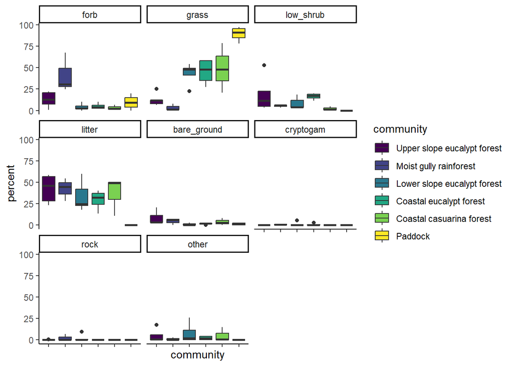

```r
  # remove white spaces in names so can work easily in ggplot
biometric_data2 <- clean_names(biometric_data) %>%
  # convert percentages to 0-100
  mutate(across(3:13, ~ .x * 100)) %>%
  # order the factors (by apperance) to match the table colour palette
  mutate(community = as_factor(community))

# break into ground cover data and convert to long format for graphing
cover <- select(biometric_data2, -c(11:16)) %>%
  pivot_longer(cols = 3:10, names_to = "feature", values_to = "percent") %>%
  mutate(feature = as_factor(feature))

# create box plot for cover
ggplot(cover) +
  geom_boxplot(aes(community, percent, fill = community)) +
  scale_fill_viridis_d() +
  facet_wrap(~feature) +
  theme_classic() +
  theme(axis.text.x=element_blank())
```

Good. We can see there are consistently low values for cryptogam, rock and bare ground, so let’s remove those to make the others easier to read.

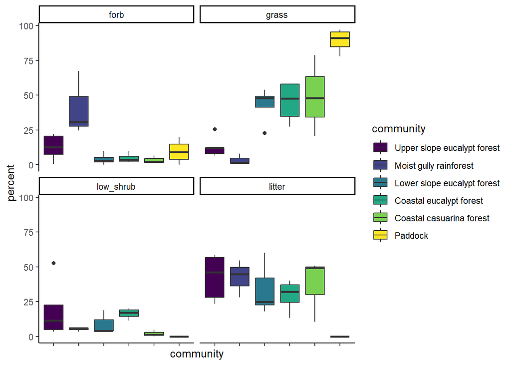

```r
cover2 <- cover %>%
  filter(feature %in% c("cover", "forb", "grass", "litter", "low_shrub"))

# create box plot for cover
ggplot(cover2) +
  geom_boxplot(aes(community, percent, fill = community)) +
  scale_fill_viridis_d() +
  facet_wrap(~feature) +
  theme_classic() +
  theme(axis.text.x=element_blank())
```

Interesting!

Now let’s look at the mid and overstory cover, plus the combined mid and overstory (called in the plot ‘cover’). The combined mid and overstory metric gives us an indication of how much light will get through to the floor (which in turn affects which plants can grow there).

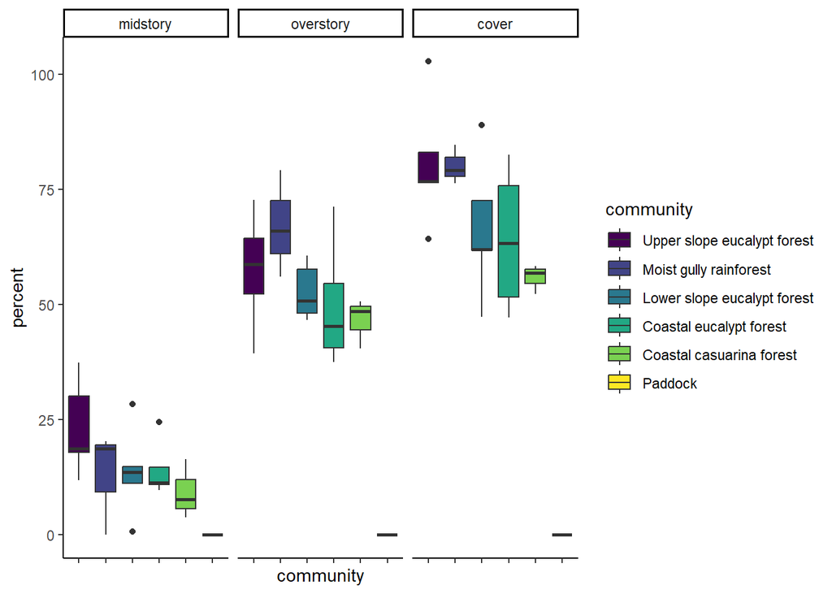

```r
# break into tree cover data and convert to long format for graphing
tree <- select(biometric_data2, -c(3:10, 14:16)) %>%
  pivot_longer(cols = 3:5, names_to = "feature", values_to = "percent") %>%
  mutate(feature = as_factor(feature))

# create box plot for cover
ggplot(tree) +
  geom_boxplot(aes(community, percent, fill = community)) +
  scale_fill_viridis_d() +
  facet_wrap(~feature) +
  theme_classic() +
  theme(axis.text.x=element_blank())
```

Now let’s look at the count biometric data: trees, trees with hollows and length of CWD.

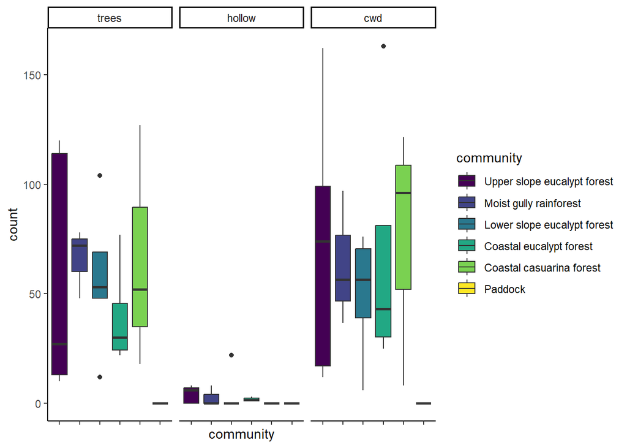

```r
# break into cover data and convert to long format for graphing
count <- select(biometric_data2, -c(3:13)) %>%
  pivot_longer(cols = 3:5, names_to = "feature", values_to = "count") %>%
  mutate(feature = as_factor(feature))

# create box plot for count
ggplot(count) +
  geom_boxplot(aes(community, count, fill = community)) +
  scale_fill_viridis_d() +
  facet_wrap(~feature) +
  theme_classic() +
  theme(axis.text.x=element_blank())
```

Great! You can use these graphs in your report.

## 3.4 Summary Statistics

And we’ll calculate the following summary statistics for all features: mean and standard deviation. You can use these numbers in the report.

```r
summary_stats <- biometric_data %>% clean_names() %>%
  pivot_longer(cols = 3:16, names_to = "feature", values_to = "value") %>%
  group_by(community, feature) %>%
  summarise(mean = mean(value),
            sd = sd(value)) %>%
  pivot_wider(names_from = 2, values_from = 3:4) %>%
  sjmisc::rotate_df(cn=TRUE) %>% slice(-1) %>%
  rownames_to_column() %>%
  rename("Stat" = 1) %>%
  separate_wider_delim(Stat, "_", names = c("Stat", "Variable"),
                       too_many = "merge") %>%
  arrange(Variable) %>%
  mutate_at(c(3:8), as.numeric)

summary_stats_table <- gt(summary_stats) %>%
  tab_options(data_row.padding = px(1)) %>%
  # change font size
  tab_style(style = cell_text(size = px(12)), locations = cells_column_labels()) %>%
  tab_style(style = cell_text(size = px(10)), locations = cells_body()) %>%
  # add header
  tab_header(title = "Biometric data summary statistics",
             subtitle = "ENVS2018 Student data Kioloa 2023") %>%
  # add source footnote
  tab_source_note(source_note = md("Note: paddock data derived from 2022")) %>%
  # drop trailing zeros
  fmt_number(drop_trailing_zeros = TRUE) %>%
  # format percentages to display %
  fmt_percent(rows = c(1,3,5,9,11,15,17,19,21,23,25), decimals = 1) %>%
    # add column colours
  tab_style(style = cell_fill(color = "#44015433"),
    locations = cells_body(columns = 8)) %>%
  tab_style(style = cell_fill(color = "#41448733"),
    locations = cells_body(columns = 6)) %>%
  tab_style(style = cell_fill(color = "#22A88433"),
    locations = cells_body(columns = 4)) %>%
  tab_style(style = cell_fill(color = "#7AD15133"),
    locations = cells_body(columns = 5)) %>%
  tab_style(style = cell_fill(color = "#FDE72533"),
    locations = cells_body(columns = 3)) %>%
  tab_style(style = cell_fill(color = "#EAEAEA"),
    locations = cells_body(columns = 7)) %>%
  # arrange columsn per other tables
  cols_move(columns = 8, after = 2) %>%
  cols_move(columns = 6, after = 3) %>%
  cols_move(columns = 5, after = 4) %>%
  cols_move(columns = 3, after = 7) %>%
  cols_move(columns = 4, after = 6) %>%
  cols_move_to_end(Paddock)

summary_stats_table
```

Biometric data summary statistics

ENVS2018 Student data Kioloa 2023

| Stat | Variable | Upper slope eucalypt forest | Moist gully rainforest | Coastal eucalypt forest | Lower slope eucalypt forest | Coastal casuarina forest | Paddock |
| --- | --- | --- | --- | --- | --- | --- | --- |
| mean | bare_ground | 8.1% | 4.4% | 1.7% | 0.8% | 3.6% | 1.2% |
| sd | bare_ground | 0.08 | 0.04 | 0.01 | 0.01 | 0.04 | 0.01 |
| mean | cover | 80.6% | 80.1% | 64.1% | 66.5% | 55.8% | 0.0% |
| sd | cover | 0.14 | 0.04 | 0.17 | 0.15 | 0.03 | 0 |
| mean | cryptogam | 0.0% | 0.7% | 0.7% | 1.1% | 0.0% | 0.0% |
| sd | cryptogam | 0 | 0.01 | 0.01 | 0.02 | 0 | 0 |
| mean | cwd | 72.8 | 63.38 | 68.5 | 49.62 | 75.13 | 0 |
| sd | cwd | 62.16 | 30.76 | 64.2 | 28.28 | 59.51 | 0 |
| mean | forb | 12.7% | 40.9% | 4.8% | 4.0% | 3.3% | 9.5% |
| sd | forb | 0.09 | 0.23 | 0.04 | 0.04 | 0.03 | 0.09 |
| mean | grass | 12.8% | 3.3% | 45.2% | 43.1% | 49.1% | 89.2% |
| sd | grass | 0.07 | 0.04 | 0.15 | 0.12 | 0.29 | 0.09 |
| mean | hollow | 4.2 | 2.67 | 1.75 | 4.4 | 0 | 0 |
| sd | hollow | 3.9 | 4.62 | 0.96 | 9.84 | 0 | 0 |
| mean | litter | 42.5% | 42.4% | 29.3% | 33.5% | 36.9% | 0.0% |
| sd | litter | 0.16 | 0.13 | 0.12 | 0.17 | 0.23 | 0 |
| mean | low_shrub | 18.9% | 5.1% | 16.3% | 8.5% | 2.0% | 0.0% |
| sd | low_shrub | 0.2 | 0.02 | 0.04 | 0.07 | 0.02 | 0 |
| mean | midstory | 23.2% | 13.0% | 14.2% | 13.7% | 9.2% | 0.0% |
| sd | midstory | 0.1 | 0.11 | 0.07 | 0.1 | 0.06 | 0 |
| mean | other | 4.8% | 0.9% | 2.0% | 7.9% | 5.1% | 0.0% |
| sd | other | 0.07 | 0.02 | 0.02 | 0.11 | 0.08 | 0 |
| mean | overstory | 57.5% | 67.1% | 49.8% | 52.8% | 46.6% | 0.0% |
| sd | overstory | 0.13 | 0.12 | 0.15 | 0.06 | 0.05 | 0 |
| mean | rock | 0.1% | 2.2% | 0.0% | 2.0% | 0.0% | 0.0% |
| sd | rock | 0 | 0.04 | 0 | 0.04 | 0 | 0 |
| mean | trees | 56.8 | 66 | 39.75 | 57.2 | 65.67 | 0 |
| sd | trees | 55.37 | 15.87 | 25.45 | 33.45 | 55.77 | 0 |

Note: paddock data derived from 2022

# 4 Bird surveys

We conducted expert bird surveys of all the plots. The observer (Sho, Julian or Belinda) recorded all birds seen and heard in a five-minute period in the following distance categories: <25m, 25-50m, 50-100m, >100m and overhead. We also asked you to estimate how many species you could identify during the survey.

## 4.1 Site visits

Let’s start by visualising and summarising the data to get our heads around it. Each site was surveyed twice, so let’s look at each visit for each site.

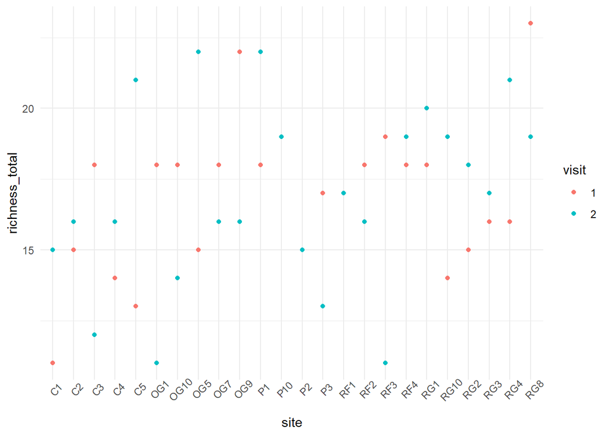

```r
# read in the data and clean names
birds_expert <- read_excel("data/ENVS2018 kioloa bird data 2023.xlsx", sheet = 1) %>%
  clean_names() %>%
  # replace NAs with zeros
  replace(is.na(.), 0) %>%
  # sum counts by species for inside (0-50m) and outside (50+m) the site, and total
  rowwise() %>%
  mutate(count_in = sum(x25 + x25_50),
         count_out = sum(x50_100 + x100 + overhead),
         count_total = sum(count_in + count_out)) %>%
  select(!c(8:12)) %>%
  mutate(present_in = ifelse(count_in>0, 1, 0),
         present_out = ifelse(count_out>0, 1, 0),
         present_total = ifelse(count_total>0, 1, 0))

# summarise by site for richness
birds_richness <- birds_expert %>% group_by(site, visit) %>%
  mutate(visit = as.factor(visit)) %>%
  summarise(richness_in = sum(present_in>0),
            richness_out = sum(present_out>0),
            richness_total = sum(present_total>0))

# plot site visits
ggplot(birds_richness)+
  geom_point(aes(site, richness_total, colour = visit)) +
  theme_minimal() +
  theme(axis.text.x = element_text(angle=45))
```

```r
# calculate differences
birds_alpha <- birds_richness %>% group_by(site) %>%
  mutate(diff = abs(richness_total - lag(richness_total))) %>%
  na.omit()

alpha_diff <- data.frame(mean = mean(birds_alpha$diff),
                        min = min(birds_alpha$diff),
                        max = max(birds_alpha$diff),
                        stdev = sd(birds_alpha$diff))

print(alpha_diff)
```

```
##       mean min max    stdev
## 1 3.583333   0   8 2.535259
```

The difference between visits was on average 4 bird species.

How about the difference in diversity detected between each visit? I.e. the beta diversity.

```r
birds_beta <- data.frame()
sites <- unique(birds_expert$site)

for (i in 1:24) {
visit1 <- filter(birds_expert, site == sites[i] & visit == 1)
visit2 <- filter(birds_expert, site == sites[i] & visit == 2)

diff_a <- setdiff(visit1$common_name, visit2$common_name)
diff_b <- setdiff(visit2$common_name, visit1$common_name)

out <- data.frame(site = sites[i], beta = length(diff_a) + length(diff_b))
birds_beta <- rbind(birds_beta, out)
}

beta_diff <- data.frame(mean = mean(birds_beta$beta),
                        min = min(birds_beta$beta),
                        max = max(birds_beta$beta),
                        stdev = sd(birds_beta$beta))

differences <- rbind(alpha_diff, beta_diff) %>%
  add_column(type = c("alpha", "beta"), .before = "mean")

print(differences)
```

```
##    type      mean min max    stdev
## 1 alpha  3.583333   0   8 2.535259
## 2  beta 14.083333   7  22 3.450478
```

Although the total difference between the visits was small, the beta diversity was greater! There was always differences in the diversity between visits (the minimum is 7) and the mean beta diversity was 14.

This is part of why we do repeat visits to site- to capture the diversity. Visits may differ by time of day (e.g. 6am or 7am) or weather.

## 4.2 Species richness

From here on we will use the total richness detected (i.e. total number of unique species across both visits).

Let’s summarise the species richness by sites. We will just do this for birds ‘in’ the site (i.e. within 50m, since then we can compare these data with the vegetation). Let’s colour these by floristic community.

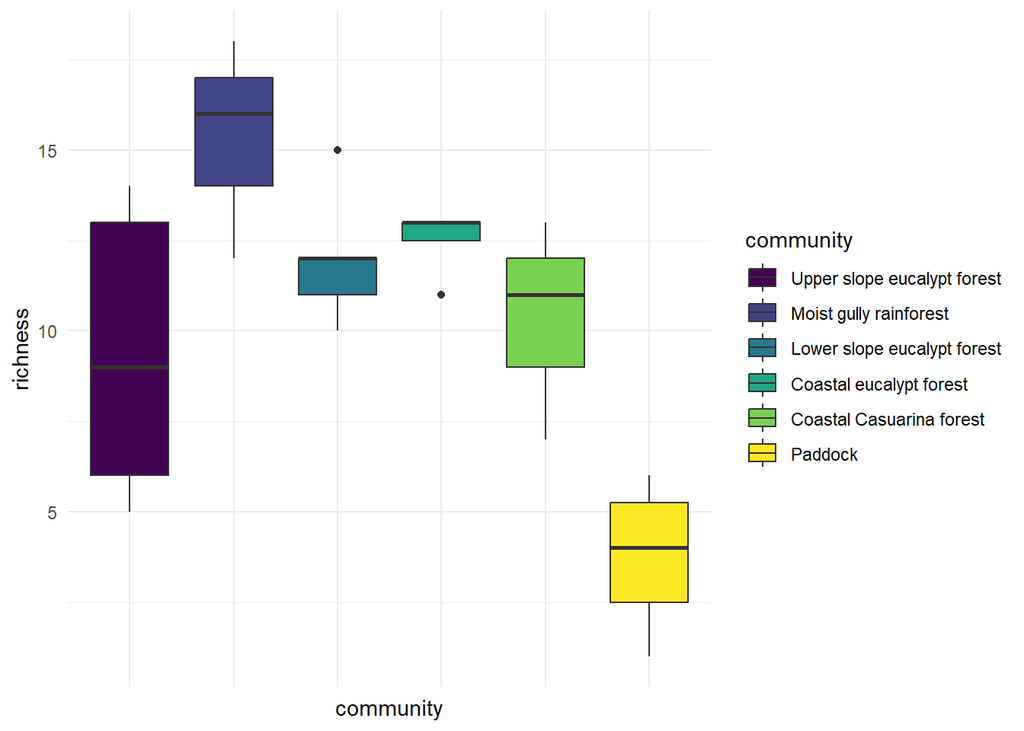

```r
# filter to birds within 50m
birds_insite <- birds_expert %>%
  filter(present_in>0) %>%
  group_by(site) %>%
  summarise(richness = length(unique(common_name)))

# format for us in the package 'vegan'
birds_vegan <- birds_expert %>%
  select(c(4,6,8)) %>%
  pivot_wider(names_from = common_name, values_from = count_in, values_fn = sum, values_fill = 0) %>%
  column_to_rownames(var = "site")

# create table of sites and communities
communities <- data.frame(site = c("OG10", "OG9", "OG7", "OG5", "RF1",
                                   "RF2", "RF3", "RF4",
                                   "RG10", "RG1", "RG3", "RG4", "RG8",
                                   "C1", "C2", "OG1", "RG2",
                                   "C3", "C4", "C5",
                                   "P10", "P1", "P2", "P3"),
                          community = c(rep("Upper slope eucalypt forest", 5,),
                                        rep("Moist gully rainforest", 3),
                                        rep("Lower slope eucalypt forest", 5),
                                        rep("Coastal eucalypt forest", 4),
                                        rep("Coastal Casuarina forest", 3),
                                        rep("Paddock", 4))) %>%
  mutate(community = as_factor(community))

# assign communities to bird data
birds_insite2 <- left_join(communities, birds_insite) %>%
  mutate(community = as_factor(community)) %>%
  arrange(community)
# set the plots in the right order for plotting
birds_insite2$site <- factor(birds_insite2$site, levels = birds_insite2$site)

# plot by community
ggplot(birds_insite2) +
  geom_boxplot(aes(community, richness, fill = community))+
  scale_fill_viridis_d()+
  theme_minimal() +
  theme(axis.text.x = element_blank())
```

```r
# summary statistics
birds_summary <- birds_insite2 %>% group_by(community) %>%
  summarise(mean_richness = mean(richness),
            stdev = sd(richness))

print(birds_summary)
```

```
## # A tibble: 6 × 3
##   community                   mean_richness stdev
##   <fct>                               <dbl> <dbl>
## 1 Upper slope eucalypt forest          9.4   4.04
## 2 Moist gully rainforest              15.3   3.06
## 3 Lower slope eucalypt forest         12     1.87
## 4 Coastal eucalypt forest             12.5   1
## 5 Coastal Casuarina forest            10.3   3.06
## 6 Paddock                              3.75  2.22
```

```r
# test if there is a difference in richness by community
richness <- specnumber(birds_vegan)
sp_aov <- aov(richness ~ community, data = communities)
anova(sp_aov)
```

```
## Analysis of Variance Table
##
## Response: richness
##           Df Sum Sq Mean Sq F value Pr(>F)
## community  5  46.54  9.3083  0.4491 0.8084
## Residuals 18 373.08 20.7269
```

Interesting! The moist gully rainforest had the highest species richness, with an average of 15.3 species. The paddock (unsuprisingly) had the lowest. There is no significant difference in bird species richness between the community types.

## 4.3 Beta diversity

But as we know, richness doesn’t tell us everything. What about beta diversity between the sites and communities?

```r
# select all birds in sites
species <- birds_expert %>%
  filter(present_in==1) %>%
  # add community
  left_join(communities)

# for loop of birds only found in that site
sites_beta <- data.frame()
sites <- unique(birds_expert$site)

for (i in 1:24) {
site_test <- species %>% filter(site == sites[i])
site_other <- species %>% filter(!site == sites[i])

diff_site <- setdiff(site_test$common_name, site_other$common_name)

if(length(diff_site) == 0){
  next
  }
out <- data.frame(site = sites[i], unique = diff_site)
sites_beta <- rbind(sites_beta, out)
}

print(sites_beta)
```

```
##    site                    unique
## 1    P3        Australasian Pipit
## 2    C5         Australian Magpie
## 3   RG4           Rufous Whistler
## 4   RG4      Variegated Fairywren
## 5   RG8            Pied Currawong
## 6   RG8       White-winged Chough
## 7   OG1   Brown-headed Honeyeater
## 8   OG1    White-naped Honeyeater
## 9    P1               Brown Quail
## 10   P1              Cattle Egret
## 11   P1            Willie Wagtail
## 12   P2              Jacky Winter
## 13   P2        White-necked Heron
## 14 RG10           Crimson Rosella
## 15 RG10                     Galah
## 16  RF2 Horsfield's Bronze-cuckoo
## 17  RF3         Brown Cuckoo-dove
## 18  OG9         Eastern Shriketit
## 19  OG9          Rainbow Lorikeet
## 20  RG1       Black-faced Monarch
## 21  RG3             Mistletoebird
```

Cool. Half of the sites had at least one unique bird species found no where else. The site with the highest count of unique birds was P1 with Brown Quail, Cattle Egret and Willie Wagtail.

Let’s now look at the unique diversity across the floristic communities.

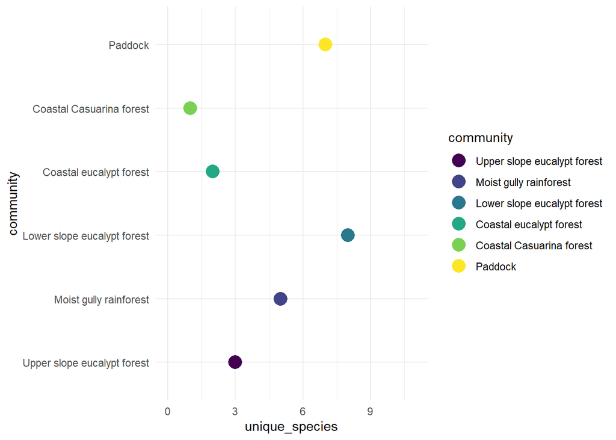

```r
# for loop of birds only found in that community
comm_beta <- data.frame()
comm <- unique(communities$community)

for (i in 1:6) {
comm_test <- species %>% filter(community == comm[i])
comm_other <- species %>% filter(!community == comm[i])

diff_comm <- setdiff(comm_test$common_name, comm_other$common_name)

if(length(diff_site) == 0){
  next
  }
out <- data.frame(community = comm[i], unique = diff_comm)
comm_beta <- rbind(comm_beta, out)
}

# summarise unique birds
comm_beta_sum <- comm_beta %>%
  mutate(community = as_factor(community)) %>%
  group_by(community) %>%
  summarise(unique_species = length(unique))

# plot unique birds by community
ggplot(comm_beta_sum)+
  geom_point(aes(unique_species, community, colour = community), size = 5) +
  scale_colour_viridis_d()+
  xlim(0,11)+
  theme_minimal()
```

```r
# print the unique birds
print(comm_beta)
```

```
##                      community                    unique
## 1  Upper slope eucalypt forest         Eastern Shriketit
## 2  Upper slope eucalypt forest        Gang Gang Cockatoo
## 3  Upper slope eucalypt forest          Rainbow Lorikeet
## 4       Moist gully rainforest         Brown Cuckoo-dove
## 5       Moist gully rainforest Horsfield's Bronze-cuckoo
## 6       Moist gully rainforest          Red-browed Finch
## 7       Moist gully rainforest                Rose Robin
## 8       Moist gully rainforest        Striated Pardalote
## 9  Lower slope eucalypt forest       Black-faced Monarch
## 10 Lower slope eucalypt forest           Crimson Rosella
## 11 Lower slope eucalypt forest                     Galah
## 12 Lower slope eucalypt forest             Mistletoebird
## 13 Lower slope eucalypt forest            Pied Currawong
## 14 Lower slope eucalypt forest           Rufous Whistler
## 15 Lower slope eucalypt forest      Variegated Fairywren
## 16 Lower slope eucalypt forest       White-winged Chough
## 17     Coastal eucalypt forest   Brown-headed Honeyeater
## 18     Coastal eucalypt forest    White-naped Honeyeater
## 19    Coastal Casuarina forest         Australian Magpie
## 20                     Paddock        Australasian Pipit
## 21                     Paddock               Brown Quail
## 22                     Paddock              Cattle Egret
## 23                     Paddock              Jacky Winter
## 24                     Paddock         White-faced Heron
## 25                     Paddock        White-necked Heron
## 26                     Paddock            Willie Wagtail
```

Very cool! There were a total of 26 bird species only found in one community type. The lower slope eucalypt forest had the greatest number of unique species (n=8) followed by the paddock (n=7).

Despite the apparent ‘lack’ of ‘habitat’ in the paddocks, there are a number of birds that are found in the paddock and nowhere else. Different birds have different requirements, some of which include open grassland areas and some are resilient to degraded landscapes. For example, the Australasian Pipit is a grassland insectivore that is mostly usually on the ground in open pasture or native grassland. It nests on the ground in tussocks.

We only found Brown Cuckoo-Dove in the rainforest, which is unsurprising since they are a rainforest species (as well as wet sclerophyll) especially found along creeks and rivers. They are largely frugivores (eating fruit and berries, but also seeds), and can eat (and disperse) hard to digest fruits. They are an important fruit disperser for rainforest plants.

These are just a couple of examples of how unique species relate to the vegetation and landscape. You could look into more of the unique species’ ecology for your report.

## 4.4 Diversity indices

We can also calculate indices for diversity aside from richness. For instance, Simpsons’s diversity index takes into account abundance as well as richness. Why do we care about abundance? Some species are not evenly distributed in the landscape, even if they are found in more than one place. This metric helps us take that into account.

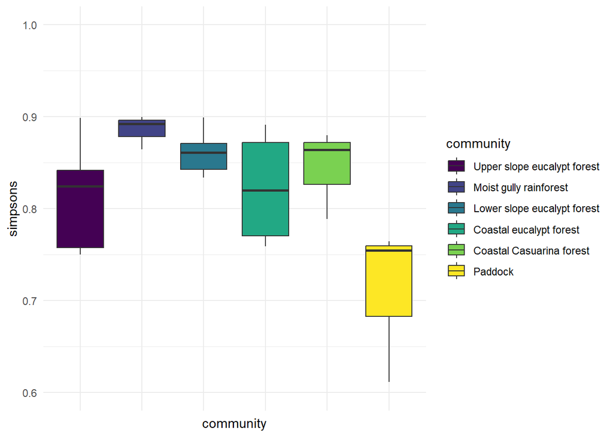

```r
# calculate simpson's diversity index for each site
simpson <- as.data.frame(diversity(birds_vegan, index = "simpson")) %>%
  rownames_to_column() %>%
  rename(site = 1,
         simpsons = 2) %>%
  left_join(communities)

simpson2 <- diversity(birds_vegan, index = "simpson")

# plot simpsons by community
ggplot(simpson) +
  geom_boxplot(aes(community, simpsons, fill = community))+
  scale_fill_viridis_d()+
  theme_minimal() +
  theme(axis.text.x = element_blank())+
  ylim(c(0.6, 1))
```

```r
# test difference
simpson_aov <- aov(simpson2 ~ community, data = communities)
anova(simpson_aov)
```

```
## Analysis of Variance Table
##
## Response: simpson2
##           Df  Sum Sq  Mean Sq F value Pr(>F)
## community  5 0.12517 0.025033  0.7063 0.6262
## Residuals 18 0.63795 0.035442
```

Note the y-axis is limited to a minimum of 0.6 to make this easier to read.

The moist gully rainforest had the highest average Simpson’s diversity index, which means it is more biodiverse in terms of both species richness and abundance. There was no significant in Simpson’s diversity index among the communities.

## 4.5 Bird communities

**(This section is interesting but you don’t have to include it in your report)**

So far we have looked at the bird richness by the floristic communities. But what about the bird communities? That is, which species tend to be together due to shared habitat features they prefer (or avoid).

We’ll use a constrained ordination to determine bird communities. An ordination examines communities across space and a contrained ordination examines communities across specific environmental variables (in our case, biometric data). The type we are doing is called ‘Canonical Correspondence Analysis’ (CCA).

For more information on how this works you can use the same tutorial I did to produce this: https://rpubs.com/an-bui/vegan-cheat-sheet

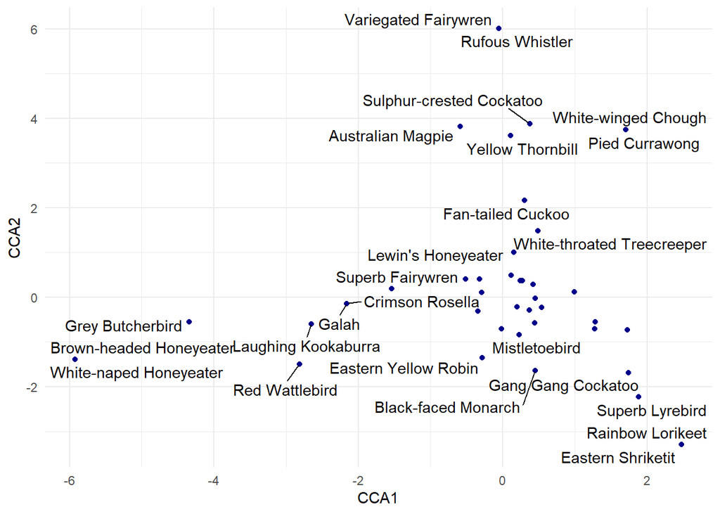

```r
# exclude paddocks because way out on their own
birds_vegan2 <- birds_vegan %>%
  rownames_to_column() %>%
  filter(!rowname %in% c("P1","P2","P3")) %>%
  column_to_rownames()

biometric_data2 <- filter(biometric_data, !Site %in% c("P1","P2","P3"))

# CCA
birdCCA <- cca(birds_vegan2 ~ Forb + Grass + Litter + Midstory + Overstory +
                 Cover + Trees + Hollow + CWD, data = biometric_data2)

# extracting the bird community data
CCA_bird <- as.data.frame(birdCCA$CCA$v) %>%
  rownames_to_column()%>%
  rename(bird = rowname)

# plot
ggplot() +
  geom_point(data = CCA_bird, aes(x = CCA1, y = CCA2), color = "darkblue")+
  geom_text_repel(data = CCA_bird, aes(x = CCA1, y = CCA2, label = bird),
                  nudge_y = -0.05) +
  theme_minimal()
```

A note: I’ve excluded the paddocks from this ordination. The paddock birds and biometrics were so distinct that it made it hard to see what was going on in the vegetated sites.

Awesome! Let’s read this figure. You can essentially ignore the axes here (arbitrary numbers in ordination space). What we are interested in is the grouping of birds. What this figure shows us is how birds cluster in the landscape according to the vegetation features (at least the ones we measured). And it looks pretty good! Not all the birds are labelled because the ones in the middle are so overlapping (read: likely to co-occur) that they didn’t get shown.

There are plenty of groupings I would expect to see here, for example Crimson Rosella, Galah, Laughing Kookaburra, Red Wattlebird and Superb Fairywren is a classic assemblage (and usually ones you see in places with human interference because all of those birds are resilient to modified and urban areas).

Likewise, Gang-Gang Cockatoo, Superb Lyrebird and Eastern Shriketit are a grouping that make sense because they are more specific in their habitat needs and were only found higher up the hill into the upper forest (the Rainbow Lorikeet is an odditity here, they only landed in the site once, so this was more due to chance).

As a final example, the cluster of birds around Yellow Thornbill is a likely community of the Casuarina forest (largely because there are more edges in this community type and the birds of this group like edges).

## 4.6 Student estimates of bird richness

And out of interest (you don’t have to include it in your report), how well did you do at estimating the bird richness at each site? Let’s compare average expert and student counts. These are total (i.e. all within 50m and >50m).

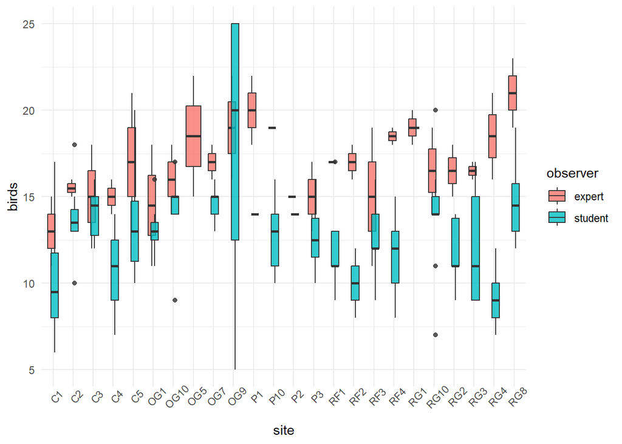

```r
# read in data
birds_student <- read_excel("data/ENVS2018 kioloa bird data 2023.xlsx", sheet = 4) %>%
  clean_names() %>%
  mutate(estimate = as.numeric(estimate)) %>%
  select(3:4) %>%
  rename(student = 2) %>%
  pivot_longer(2, names_to = "observer", values_to = "birds")

# combine expert and student
birds_compare <- birds_richness %>%
  select(c(1,5)) %>%
  rename(expert = 2) %>%
  pivot_longer(2, names_to = "observer", values_to = "birds") %>%
  rbind(birds_student)

# plot expert and student
ggplot(birds_compare)+
  geom_boxplot(aes(site, birds, fill = observer), alpha = .8,
               position=position_dodge(width=.3)) +
  theme_minimal()+
  theme(axis.text.x = element_text(angle=45))
```

In general, you underestimated the total number of species- which is to be expected! It takes a lot of practice and patience to learn bird calls. I hope you enjoyed coming out on the bird surveys with us and I appreciated your enthusiasm despite the early start!

## 4.7 Acoustic data

**(This section is interesting but you don’t have to include it in your report)**

You also surveyed the sites using acoustic meters. We collected data for two hours around dusk and dawn for one night. One of the benefits of acoustic meters is they can help sample diversity that otherwise would be missed in the time constraints of a five-minute count. The other benefit was to teach you how to use this kit and read sonograms! Let’s see what we detected. First we’ll look at the effect of time of day.

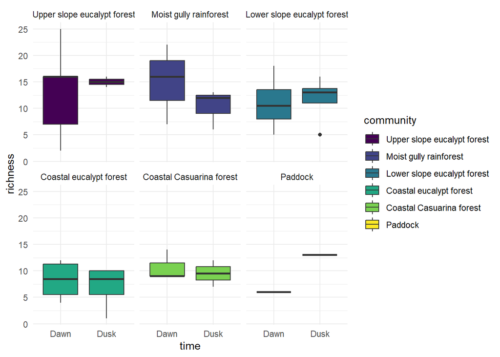

```r
# read in
acoustic <- read_excel("data/ENVS2018 kioloa acoustic data 2023.xlsx", sheet = 1) %>%
  clean_names()

acoustic_rich <- acoustic %>% group_by(site,time) %>%
  summarise(richness = length(unique(common_name))) %>%
  left_join(communities) %>%
  mutate(type = "acoustic")

# plot by site and dusk/dawn
ggplot(acoustic_rich)+
  geom_boxplot(aes(time, richness, fill = community))+
  facet_wrap(~community)+
  scale_fill_viridis_d()+
  theme_minimal()
```

```r
# test difference dusk and dawn
tod <- aov(richness ~ time, data = acoustic_rich)
anova(tod)
```

```
## Analysis of Variance Table
##
## Response: richness
##           Df Sum Sq Mean Sq F value Pr(>F)
## time       1   2.63  2.6331  0.0924 0.7629
## Residuals 35 997.26 28.4931
```

There was no difference in the richness recorded between dusk and dawn. Note: only one paddock site (P10) had an acoustic meter.

How did the richness detected on the acoustic meters compare with the bird surveys?

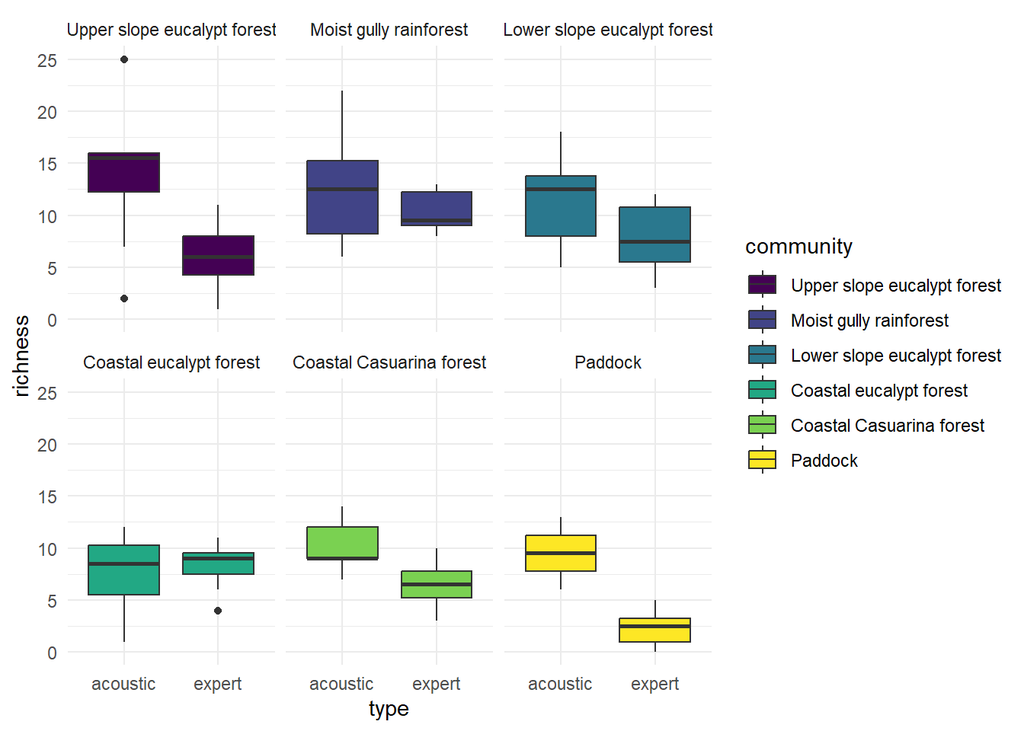

```r
# combine acoustic and expert bird counts
acoustic_compare <- select(birds_richness, c(1,3)) %>%
  rename(richness = 2) %>%
  mutate(type = "expert") %>%
  left_join(communities) %>%
  full_join(select(acoustic_rich, !2))

# plot comparison
ggplot(acoustic_compare) +
  geom_boxplot(aes(type, richness, fill = community))+
  scale_fill_viridis_d()+
  facet_wrap(~community)+
  theme_minimal()
```

```r
# test difference
aco <- aov(richness ~ type, data = acoustic_compare)
anova(aco)
```

```
## Analysis of Variance Table
##
## Response: richness
##           Df Sum Sq Mean Sq F value    Pr(>F)
## type       1  375.9  375.90  20.165 2.273e-05 ***
## Residuals 83 1547.2   18.64
## ---
## Signif. codes:  0 '***' 0.001 '**' 0.01 '*' 0.05 '.' 0.1 ' ' 1
```

Wow! We detected significantly more bird species on the acoustic meters than in the 5-minute expert counts (only considering the species within the 50m radius).

A caveat here is that we simply used ‘loudness’ of the acoustic data as a proxy for distance, so the two aren’t directly comparable. For example, the Wood Duck heard on the acoustic meter might have been further away than 50m because their ‘waaaaa’ call carries. We could have tested this by playing a known volume tone at 50m from the meters to figure out how ‘loud’ something needs to be to be in the site.

You can imagine the addition of time to a bird survey as a curve of diminishing returns- you add more time, you get more species, but at a decaying rate of increase over time. So we could achieve higher richness counts by doing say, a 15-minute or even 1-hour bird survey (imagine that!), but that would not be a good use of people-time. This is where acoustic meters can come in handy.

Another important use of acoustic meters is to detect rare things that don’t call often. If you were tasked with finding a Night Parrot, you would have to spend 1000s of hours in the remote spinifex desert to potentially hear a short call; which is why agencies like Parks and NGOs such as AWC instead deploy acoustic meters and then use AI to scan through in search of the target species.

How about the beta diversity between the acoustic and expert counts?

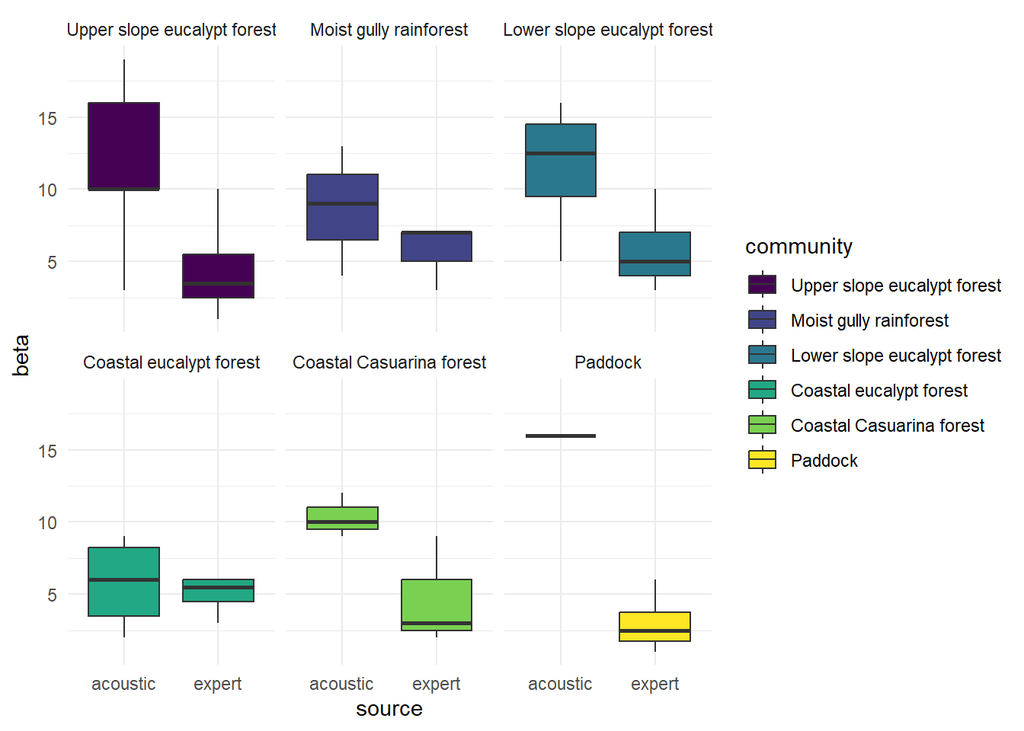

```r
# for loop of birds only found in that community
aco_beta <- data.frame()
species2 <- species %>% filter(present_in==1)

for (i in 1:24) {
uni_exp <- species2 %>% filter(site == sites[i])
uni_aco <- acoustic %>% filter(site == sites[i])

diff1 <- setdiff(uni_exp$common_name, uni_aco$common_name) %>%
  as.data.frame() %>%
  rename(unique = 1) %>%
  mutate(source = "expert",
         site = sites[i])
diff2 <- setdiff(uni_aco$common_name, uni_exp$common_name)%>%
  as.data.frame() %>%
  rename(unique = 1) %>%
  mutate(source = "acoustic",
         site = sites[i])

aco_beta <- rbind(aco_beta, diff1, diff2)
}

aco_beta2 <- aco_beta %>%
  group_by(site, source) %>%
  summarise(beta = length(unique(unique))) %>%
  left_join(communities)

# plot difference
ggplot(aco_beta2)+
  geom_boxplot(aes(source, beta, fill=community))+
  scale_fill_viridis_d()+
  facet_wrap(~community)+
  theme_minimal()
```

```r
# test difference
aco_b <- aov(beta ~ source, data = aco_beta2)
anova(aco_b)
```

```
## Analysis of Variance Table
##
## Response: beta
##           Df Sum Sq Mean Sq F value    Pr(>F)
## source     1 291.20 291.203  20.171 5.664e-05 ***
## Residuals 41 591.91  14.437
## ---
## Signif. codes:  0 '***' 0.001 '**' 0.01 '*' 0.05 '.' 0.1 ' ' 1
```

While we found unique species between both methods, there were significantly more unique species found on the acoustic meters that we didn’t detect during the expert counts (if we only consider expert counts within the site- this is important because if we include birds outside of the sites we actually detect more birds with the expert surveys. The people can hear further than the units).

Aside from the study sits, were there any unique species found only on the expert counts or acoustic meters across the whole campus?

```r
b_exp <- setdiff(species2$common_name, acoustic$common_name) %>%
  as.data.frame() %>%
  rename(unique = 1) %>%
  mutate(source = "expert")

b_aco <- setdiff(acoustic$common_name, species2$common_name)%>%
  as.data.frame() %>%
  rename(unique = 1) %>%
  mutate(source = "acoustic")

aco_beta3 <- rbind(b_exp, b_aco)

print(aco_beta3)
```

```
##                      unique   source
## 1        Australasian Pipit   expert
## 2       Black-faced Monarch   expert
## 3         Brown Cuckoo-dove   expert
## 4               Brown Quail   expert
## 5              Cattle Egret   expert
## 6        Gang Gang Cockatoo   expert
## 7              Jacky Winter   expert
## 8                Rose Robin   expert
## 9  Sulphur-crested Cockatoo   expert
## 10     Variegated Fairywren   expert
## 11        White-faced Heron   expert
## 12       White-necked Heron   expert
## 13      White-winged Chough   expert
## 14           Bassian Thrush acoustic
## 15               Bell Miner acoustic
## 16 Black-faced Cuckooshrike acoustic
## 17   Common Eastern Froglet acoustic
## 18      Crescent Honeyeater acoustic
## 19              King Parrot acoustic
## 20        Little Wattlebird acoustic
## 21           Masked Lapwing acoustic
## 22   New Holland Honeyeater acoustic
## 23           Rufous Fantail acoustic
## 24          Satin Bowerbird acoustic
## 25    Shining Bronze-Cuckoo acoustic
## 26  White-bellied Sea Eagle acoustic
## 27             Wonga Pigeon acoustic
## 28                Wood Duck acoustic
```

Cool! Some of these species were detected during the bird surveys but not within the site itself (i.e. heard at a distance instead of within 50m). For example, we heard King Parrots during the expert counts but not in the sites.

What about out of the sites? Let’s sum up the total richness of birds recorded across the whole campus from both methods

```r
# all bird species
species_expert <- data.frame(species = unique(birds_expert$common_name),
                             type = "expert")
species_acoustic <- data.frame(species = unique(acoustic$common_name),
                             type = "acoustic")

species_all <- rbind(species_expert, species_acoustic) %>%
  mutate(type = ifelse(duplicated2(species, bothWays=TRUE)==TRUE,"both",type)) %>%
  #remove the frog
  filter(!species == "Common Eastern Froglet") %>%
  distinct()

# make gt table
species_all %>%
  group_by(type) %>%
  gt() %>%
  tab_options(data_row.padding = px(1)) %>%
  # change font size
  tab_style(style = cell_text(size = px(12)), locations = cells_column_labels()) %>%
  tab_style(style = cell_text(size = px(10)), locations = cells_body())
```

| species |
| --- |
| expert |
| Australasian Pipit |
| Black-faced Monarch |
| Brown Cuckoo-dove |
| Brown Falcon |
| Brown Quail |
| Cattle Egret |
| Gang Gang Cockatoo |
| Jacky Winter |
| Little Black Cormorant |
| Little Corella |
| Magpie Lark |
| Noisy Friarbird |
| Red-rumped Parrot |
| Rose Robin |
| Scarlet Robin |
| Sulphur-crested Cockatoo |
| Topknot Pigeon |
| Variegated Fairywren |
| Welcome Swallow |
| White-faced Heron |
| White-necked Heron |
| White-winged Chough |
| Yellow-tailed Black Cockatoo |
| both |
| Australian Magpie |
| Australian Raven |
| Black-faced Cuckooshrike |
| Brown Gerygone |
| Brown Thornbill |
| Brown-headed Honeyeater |
| Crimson Rosella |
| Eastern Shriketit |
| Eastern Spinebill |
| Eastern Whipbird |
| Eastern Yellow Robin |
| Fan-tailed Cuckoo |
| Galah |
| Golden Whistler |
| Grey Butcherbird |
| Grey Fantail |
| Grey Shrikethrush |
| Horsfield's Bronze-cuckoo |
| King Parrot |
| Laughing Kookaburra |
| Lewin's Honeyeater |
| Little Wattlebird |
| Masked Lapwing |
| Mistletoebird |
| New Holland Honeyeater |
| Olive-backed Oriole |
| Pied Currawong |
| Rainbow Lorikeet |
| Red Wattlebird |
| Red-browed Finch |
| Rufous Whistler |
| Satin Bowerbird |
| Scarlet Honeyeater |
| Silvereye |
| Spotted Pardalote |
| Striated Pardalote |
| Striated Thornbill |
| Superb Fairywren |
| Superb Lyrebird |
| White-browed Scrubwren |
| White-naped Honeyeater |
| White-throated Treecreeper |
| Willie Wagtail |
| Wonga Pigeon |
| Wood Duck |
| Yellow Thornbill |
| Yellow-faced Honeyeater |
| acoustic |
| Bassian Thrush |
| Bell Miner |
| Crescent Honeyeater |
| Rufous Fantail |
| Shining Bronze-Cuckoo |
| White-bellied Sea Eagle |

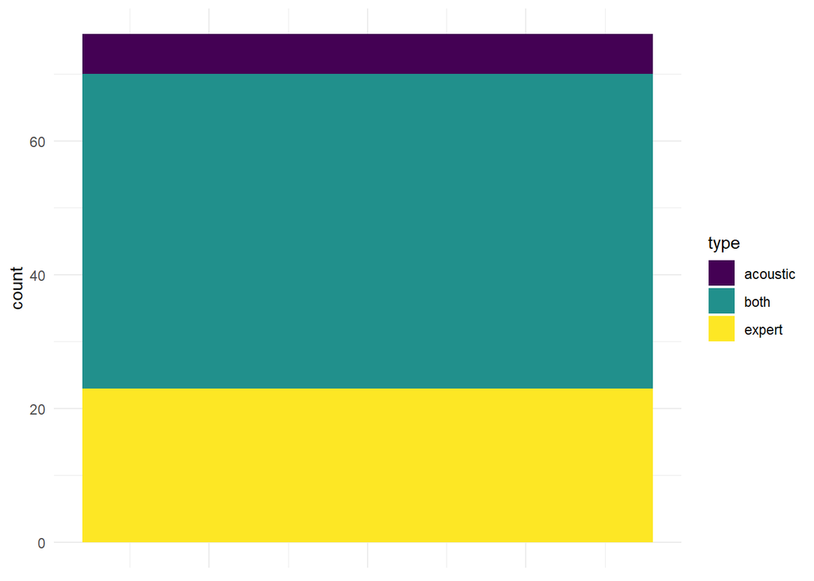

```r
species_all2 <- species_all %>%
  group_by(type) %>%
  summarise(count = length(species))

# plot
ggplot(species_all2,aes(1,count,fill=type))+
  geom_bar(stat="identity")+
  scale_fill_viridis_d()+
  theme_minimal()+
    theme(axis.title.x=element_blank(),
        axis.text.x=element_blank(),
        axis.ticks.x=element_blank())
```

We detected a total of 76 bird species. Of these, 47 were detected on both the acoustic meters and in the bird surveys, where 23 were only detected on the expert counts and 6 in the acoustics.

Species that were uniquely recorded on the acoustic meters (and not in the total expert counts including out of sites) were: Bassian Thrush, Bell Miner, Crescent Honeyeater, Rufous Fantail, Shining Bronze-Cuckoo and White-bellied Sea Eagle (which have a nest in site RG1 were they were recorded). These 6 species were added to the total site richness thanks to the acoustic meter!

# 5 Other wildlife results

You don’t have to report on this section, but we wanted to show you some interesting findings.

## 5.1 Cameras

Let’s have a look at how our camera results compared with previous years.

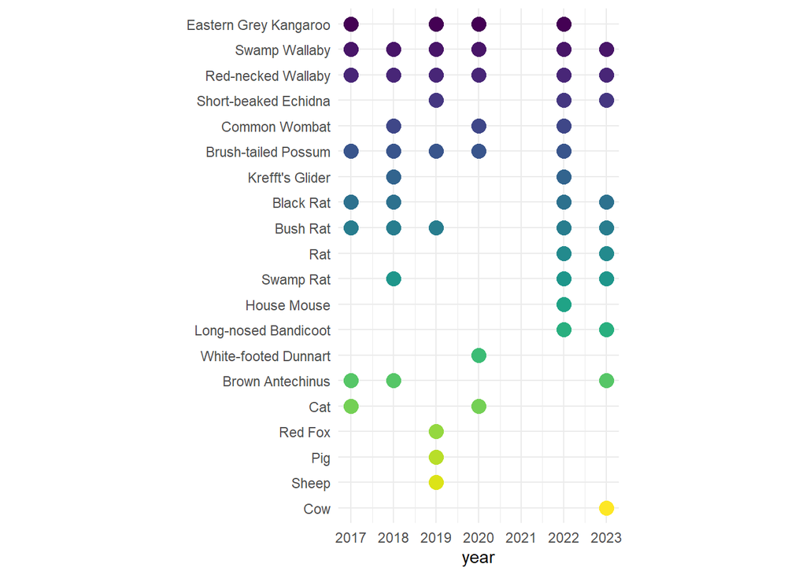

```r
# groups
mammals <- c("Eastern Grey Kangaroo", "Swamp Wallaby", "Red-necked Wallaby",
             "Short-beaked Echidna", "Common Wombat",
             "Brush-tailed Possum", "Krefft's Glider",
             "Black Rat", "Bush Rat", "Rat", "Swamp Rat", "House Mouse",
             "Long-nosed Bandicoot", "White-footed Dunnart", "Brown Antechinus",
             "Cat", "Red Fox", "Pig" , "Sheep", "Cow")

# read in data
camera <- read_excel("data/ENVS2018 kioloa data 2017-2023.xlsx", sheet = 2) %>%
  clean_names() %>%
  distinct() %>%
  #remove skinks
  filter(!common_name == "Delicate Sun-skink") %>%
  mutate(taxa = ifelse(common_name %in% mammals, "mammal", "bird")) %>%
  filter(taxa == "mammal") %>%
  mutate(common_name = factor(common_name, levels = mammals))

# plot mammals
ggplot(camera)+
  geom_point(aes(year, common_name, colour = common_name), size = 4)+
  scale_colour_viridis_d()+
  theme_minimal()+
  theme(legend.position= "none")+
  theme(axis.title.y=element_blank())+
  scale_y_discrete(limits=rev)+
  scale_x_continuous(n.breaks = 7)+
  coord_fixed(ratio = 0.6)
```

Here we can see which species were seen in which years. The occurrence of these species might relate to environmental conditions (e.g. drought). Note: the cameras were not placed in rainforest and coastal locations in 2017-2020, only upper and lower slope eucalypt forest and paddock. Also note there was a bushfire in the 2019/2020 Summer. No data was collected in 2021 (covid-19).

## 5.2 Herpetofauna

Let’s do the same thing with the reptiles and frogs (from tin/tile and opportunistic records).

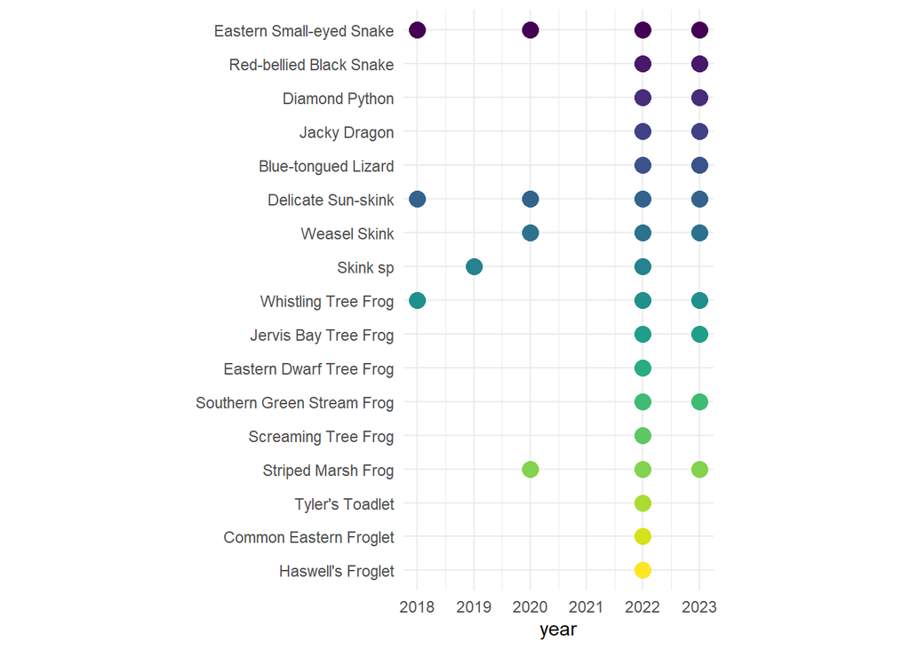

```r
# read in data
herpsp <- c("Eastern Small-eyed Snake", "Red-bellied Black Snake", "Diamond Python",
            "Jacky Dragon", "Blue-tongued Lizard", "Delicate Sun-skink",
            "Weasel Skink", "Skink sp", "Whistling Tree Frog", "Jervis Bay Tree Frog",
            "Eastern Dwarf Tree Frog", "Southern Green Stream Frog",
            "Screaming Tree Frog", "Striped Marsh Frog", "Tyler's Toadlet",
            "Common Eastern Froglet", "Haswell's Froglet")

herps <- read_excel("data/ENVS2018 kioloa data 2017-2023.xlsx", sheet = 1) %>%
  clean_names() %>%
  select(2:3) %>%
  # remove mice
  filter(!common_name == "House Mouse") %>%
  distinct() %>%
  mutate(common_name = factor(common_name, levels = herpsp))

# plot
ggplot(herps)+
  geom_point(aes(year, common_name, colour = common_name), size = 4)+
  scale_colour_viridis_d()+
  theme_minimal()+
  theme(legend.position= "none")+
  theme(axis.title.y=element_blank())+
  scale_y_discrete(limits=rev)+
  scale_x_continuous(n.breaks = 7)+
  coord_fixed(ratio = 0.6)
```

This is really an indication of the survey effort for herpetofauna! In 2018-2020 we only had tin/tile (AKA substrate) checks (which were done by students instead of expert observers) whereas in 2022 we started recording incidental sightings and doing the pond frog surveys.

I wonder how these results compare with the frog diversity in the pre-readings?

## 5.3 Birds over time

Lastly, let’s look at how the bird diversity has changed over the years (remember you do not need to include this in your report). We’ll only be able to compare over the sites labelled ‘OG’, ‘RG’ and ‘P’ since these are consistent over all years (‘RF’ and ‘C’ added in 2022).

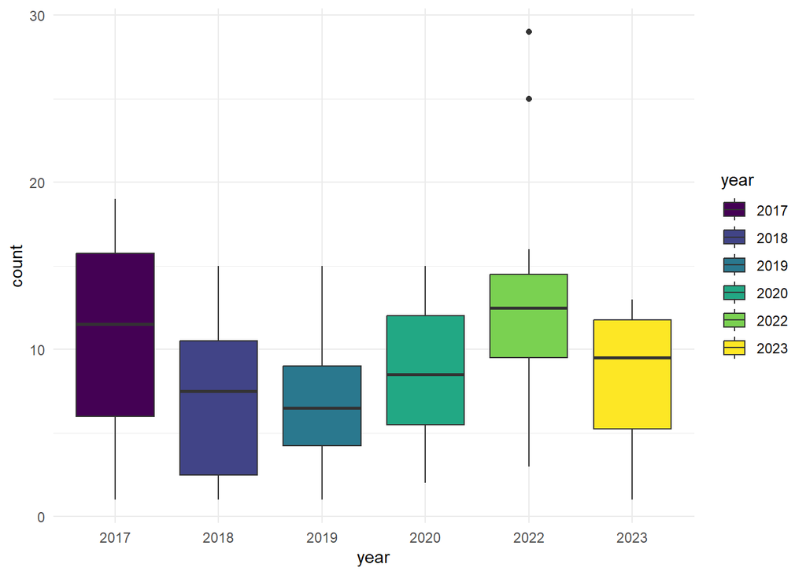

```r
# read in data
sites_consistent <- c("P3", "RG2", "RG1", "OG7", "RG10", "OG1", "OG5", "OG10", "OG9", "RG8", "P10", "RG3", "P2", "P1")

birds_years <- read_excel("data/ENVS2018 kioloa data 2017-2023.xlsx", sheet = 4) %>%
  clean_names() %>%
  # remove birds outside of survey points
  filter(radius == "0-50") %>%
  select(c(1,2,4)) %>%
  # filter to sites in all years
  filter(site %in% sites_consistent)

# summarise by year and site
birds_year_sum <- birds_years %>% group_by(year, site) %>%
  summarise(count = length(unique(species))) %>%
  mutate(year = as.factor(year),
         site = as.factor(site))

# plot by year
ggplot(birds_year_sum)+
  geom_boxplot(aes(year, count, group=year, fill = year))+
  scale_fill_viridis_d()+
  theme_minimal()
```

And over the years between sites.

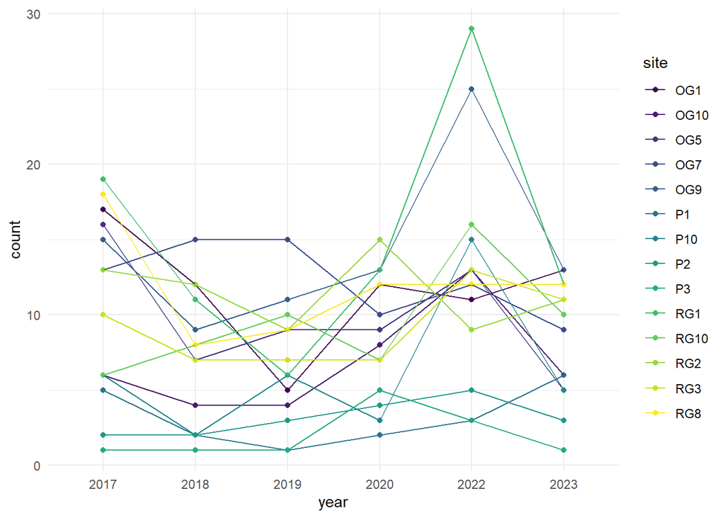

```r
# plot by site
ggplot(birds_year_sum)+
  geom_point(aes(year, count, colour = site))+
  geom_line(aes(year, count, group = site, colour = site))+
  scale_colour_viridis_d()+
  theme_minimal()
```

And lastly, some summary data

```r
#summary
birds_year_sum %>%
  group_by(year) %>%
  summarise(mean = mean(count),
            max = max(count),
            min = min(count),
            sd = sd(count)) %>%
  gt() %>%
  tab_style(style = cell_text(size = px(12)), locations = cells_body())
```

| year | mean | max | min | sd |
| --- | --- | --- | --- | --- |
| 2017 | 10.500000 | 19 | 1 | 6.123724 |
| 2018 | 7.142857 | 15 | 1 | 4.435125 |
| 2019 | 6.857143 | 15 | 1 | 3.958577 |
| 2020 | 8.571429 | 15 | 2 | 4.108421 |
| 2022 | 12.785714 | 29 | 3 | 7.329378 |
| 2023 | 8.357143 | 13 | 1 | 3.953716 |

I hope you enjoyed reading this data summary. This is the first time we have done the report this way so it was for for me to look at all the data!

Good luck with the report writing!